# Lecture_01.R-efresher.JupyterHub.live

[figure not shown]

## Advanced Graphics and Data Visualization in R

## Lecture 01: "R"-efresher on R and best practices

## 0.1.0 An overview of Advanced Graphics and Data Visualization in R

**"Advanced Graphics and Data Visualization in R"** is brought to you by the Centre for the Analysis of Genome Evolution & Function's (CAGEF) bioinformatics training initiative. CSB1021 was developed to enhance the skills of students with basic backgrounds in R by focusing on available philosophies, methods, and packages for plotting scientific data. While the datasets and examples used in this course will be centred on SARS-CoV-2 datasets, the techniques learned herein will be broadly applicable.

This lesson is the first in a 6-part series. The aim for the end of this series is for students to recognize how to import, format, and display data based on their intended message and audience. The format and style of these visualizations will help to identify and convey the key message(s) from their experimental data.

The structure of the class is a **code-along style** in Jupyter notebooks. At the start of each lecture, skeleton versions of the lecture will be provided for use on the [University of Toronto Jupyter Hub](https://jupyter.utoronto.ca/hub/login) so students can program along with the instructor.

## 0.2.0 Lecture objectives

This week will be your crash-course on Jupyter notebooks and R to refresh on packages and principles that will be relevant throughout our course. In our lectures and your assignments we will be working with some uncurated data to simulate the full experience of working with data from start to finish. It's important that we are all familiar with, and understand the majority of the tidy data methods that we'll be using in class so that we can focus on the new material as it appears. We'll use some standard packages and practices to finesse our data before visualizing it, so let's R-efresh ourselves.

At the end of this lecture we will have covered the following topics:

1. Working with Jupyter notebooks and best coding practices.
2. R data types, objects and working with them.
3. Long-format and tidy data principles using the `tidyverse` package.
4. Basic control flow and plotting.

## 0.3.0 A legend for text format in Jupyter markdown

`grey background` - a package, function, code, command or directory. Backticks are also use for in-line code.  
*italics* - an important term or concept or an individual file or folder  
**bold** - heading or a term that is being defined  
blue text - named or unnamed hyperlink

`...` - Within each coding cell this will indicate an area of code that students will need to complete for the code cell to run correctly.

**Blue box:** A key concept that is being introduced

**Yellow box:** Risk or caution

**Green boxes:** Recommended reads and resources to learn Python

**Red boxes:** A comprehension question which may or may not involve a coding cell. You usually find these at the end of a section.

## 0.4.0 Lecture and data files used in this course

### 0.4.1 Weekly Lecture and skeleton files

Each week, new lesson files will appear within your JupyterHub folders. We are pulling from a GitHub repository using this [Repository git-pull link](https://jupyter.utoronto.ca/hub/user-redirect/git-pull?repo=https%3A%2F%2Fgithub.com%2Fcamok%2F2023-03-Adv_Graphics_R&urlpath=tree%2F2023-03-Adv_Graphics_R%2F&branch=main). Simply click on the link and it will take you to the University of Toronto JupyterHub. You will need to use your UTORid credentials to complete the login process. From there you will find each week's lecture files in the directory `/2023-03-Adv_Graphics_R/Lecture_XX`. You will find a partially coded `skeleton.ipynb` file as well as all of the data files necessary to run the week's lecture.

Alternatively, you can download the Jupyter Notebook (`.ipynb`) and data files from JupyterHub to your personal computer if you would like to run independently of the JupyterHub.

### 0.4.2 Live-coding HTML page

A live lecture version will be available at [camok.github.io](https://camok.github.io/2023-03.Adv_Graphics_R/index.html) that will update as the lecture progresses. Be sure to refresh to take a look if you get lost!

### 0.4.3 Post-lecture PDFs and Recordings

As mentioned above, at the end of each lecture there will be a completed version of the lecture code released as a PDF file under the Modules section of Quercus.

### 0.4.4 Data used in this lesson

Today's datasets will focus on epidemiological data from the Ontario provincial government found [here](https://data.ontario.ca/dataset/status-of-covid-19-cases-in-ontario) and [here](https://data.ontario.ca/en/dataset/covid-19-cases-in-hospital-and-icu-by-ontario-health-region).

### 0.4.4.2 Dataset 2: region_hospital_icu_covid_data.csv

This dataset was obtained from the Ontario provincial website and holds data regarding SARS-CoV-2 throughout 5 Ontario health regions. It is in a comma-separated format and has been growing/expanding since initial tracking started on 2020-04-02. This is a dataset only tracks 7 variables specifically regarding the daily totals of hospitalized COVID-19 patients both in the ICU and general care.

## 0.5.0 Packages used in this lesson

`repr`- a package useful for altering some of the attributes of objects related to the R kernel.

`tidyverse` which has a number of packages including `dplyr`, `tidyr`, `stringr`, `forcats` and `ggplot2`

`viridis` helps to create color-blind palettes for our data visualizations

`lubridate` and `zoo` are helper packages used for working with date formats in R

Let's run our first code cell!

```r
# Packages to help tidy our data
library(tidyverse)

# Packages for the graphical analysis section
library(repr)
library(viridis)

# packages used for working with/formating dates in R
library(lubridate)
library(zoo)
```

# 1.0.0 Coding in Jupyter Notebooks

Work with your Jupyter Notebook on the University of Toronto JupyterHub will all be contained within a new browser tab with the address bar showing something similar to

`https://jupyter.utoronto.ca/user/assigned-username-hexadecimal/tree/2023.03_Adv_Graphics_R`

All of this is running remotely on a University of Toronto server rather than your own machine.

You'll see a directory structure from your home folder:

ie `\2023.03-Adv_Graphics_R\` and a folder to `Lecture_01_R_Introduction` within. Clicking on that, you'll find `Lecture_01.R-efresher.skeleton.ipynb` which is the notebook we will use for today's code-along lecture.

## 1.1.0 Why is this class using Jupyter Notebooks?

We've implemented the class this way to reduce the burden of having to install various programs. While installation can be a *little* tricky, it's really not that bad. For this introduction course, however, you don't need to go through all of that just to improve on your data visualization skills.

Jupyter Notebooks also give us the option of inserting "markdown" text much like what you're reading at this very *exact* moment. So we can intersperse ideas and information between our learning code blocks.

There is, however an appendix section at the end of this lecture detailing how to install Jupyter Notebooks (and the R-kernel for them) as well as independent installation of the R-kernel itself and a great integrated development environment (IDE) called RStudio.

## 1.2.0 Packages contain useful functions that we'll use often

So... what are in these packages? A **package** can be a collection of

- functions
- data objects
- compiled code
- functions that *override* base functions in R

**Functions** are the basic workhorses of R; they are the tools we use to analyze our data. Each function can be thought of as a unit that has a specific task. A function takes an input, evaluates it using an expression (e.g. a calculation, plot, merge, etc.), and returns an output (a single value, multiple values, a graphic, etc.).

In this course we will frequently rely on a package called `tidyverse` which is also composed of a series of other packages we can use to reformat our data like `readr`, `dplyr`, `tidyr` and `stringr`.

## 1.3.0 Jupyter notebooks run programming language kernels like R

Behind the scenes of each Jupyter notebook a programming kernel is running. For instance, depending on setup our notebooks can run a true or "emulated" R-kernel to interpret each code cell as if it were written specifically for the R language.

As we move from code cell to new code cell, all of the variables or objects we have created are stored within memory. We can refer to these as we run the code and move forward but if you overwrite or change them by mistake, you may to have rerun multiple cell blocks!

There are some options in the "Cell" menu that can alleviate these problems such as "Run All Above". If you think you've made a big error by overwriting a key object, you can use that option to "re-initialize" all of your previous code!

The run order of your code is also visible at the side of each code cell as `[x]`. When a code cell is still actively running it will be denoted as `[*]` since a number cannot be assigned to it. You'll also notice your kernel (top right of the menu bar) has a small circle that will be dark while running, and clear while idle.

**Remember these friendly keys/shortcuts:**

- `Esc` to enter "Command Mode" which basically takes you outside of the cell.
- `Enter` to edit a cell
- `Arrow` keys to navigate up and down (and within a cell)
- `Ctrl`+`Enter` to run a cell (both code and markdown)
- `Shift`+`Enter` to run the current cell and move to the next one below
- `Ctrl`+`/` to quickly comment and uncomment single or multiple lines of code
- `Tab` can be used while coding to autocomplete variable, function and file names, and even look at a list of possible parameters for functions.
- `Shift` + `L` to toggle line numbers within markdown and code cells.

In Command mode

- `a` insert a new cell **a**bove the currently selected cell
- `b` insert a new cell **b**elow the currently selected cell ** Note that cells are defaulted to code cells
- `m` converts a section to a **m**arkdown cell
- `y` converts a section to a **c**ode cell
- `r` converts a section to a **r**aw__ nbconvert cell. This is most helpful when wishing to preserve a code format without running it through the kernel.

### 1.3.1 Navigating the menu bar

If you can't remember your keyboard shortcuts, you can always access the same commands (and more!) through the menu bar.

- **File**: New, Open, Make a copy, Save as, Rename, Save and Checkpoint, Download as, Close and Halt.
- **Edit**: Cut, Copy, Paste, Delete, Split, Merge, Move, Find, Insert Image, nbextension config (alter your setting here)
- **View**: Toggle Header, Toggle Toolbar, Toggle Line Numbers
- **Insert**: Insert Cell Above/Below
- **Cell**: Run Cells, Run and Select Below, Run and Insert Below, etc. You can also clear and toggle cell output from here.
- **Kernel**: Sometimes you need to restart or shut them down
- **Help**: General help options about Jupyter and references to widely used Python libraries such as NumPy, SciPy, and Pandas.

<sup>1</sup>kernels are separate processes to run code that are started by the server that runs your code.

### 1.3.2 Jupyter Dashboard tab

- **Files**: Directories and files in your current working directory.
- **Running**: A complete list of all the kernels currently active. You can end stalled notebooks from here too.
- **Nbextensions**: lists all of the configurations and extensions for your notebook (if you're running a custom installation)

### 1.3.3 Why would you want to use a Jupyter Notebook?

Depending on your needs, you may find yourself doing the following:

- Analysing data for your project using available packages
- Re-analysing data for your project
- Analysing multiple datasets for your project
- Collaborating on data and analyses for your project
- **Explaining** your data and analyses to a supervisor or collaborator!

Jupyter allows you to alternate between "markdown" notes and "code" that can be run or re-run on the fly.

Each data run and it's results can be saved individually as a new notebook to compare data and small changes to analyses!

### 1.3.4 What is markdown language?

Markdown is a markup language that lets you write HTML and Java Script code in combination with other languages. This allows you to make html, pdf, and text documents that are combinations of text and code, enhancing reproducibility, a key aspect in scientific work. Having everything in a single place also boosts productivity during results interpretation - no need to go back and forth between tabs, pages, and documents. They can all be integrated in a single document, allowing for a more fluid narrative of the story that you are communicating to your audience (less distractions for you!). For example, the lines of code below and the text you are reading right now were created in Jupyter Lab's Markdown. (Do not worry about the Python code just yet. We will get there sooner than you think).

As mentioned, Jupyter also allows you to write in [LaTeX](https://www.latex-project.org/about/), a document preparation system to write mathematical notation. All it takes is to wrap LaTeX code between single dollar signs (\$) for inline notation or two double dollar signs (\\$\$), one at the beginning of the equation and one at the end. For example, the equation ***Yi = beta0 + beta1 xi + epsilon_i, i=1, ..., N*** can be transformed into LaTeX code by adding some characters: ***Y_i = \beta_0 + \beta_1 x_i + \varepsilon_i, i=1, \dots, N***. Now, if we use \\$\$ before and after the LaTeX code, this is what we get:

$$ Y_i = \beta_0 + \beta_1 x_i + \varepsilon_i, i=1, \dots,N $$

See? Just like that! Here is an example of a table made in Markdown, showing some of the most popular Python libraries for data science:

| Library | Use |
| --- | --- |
| Pandas | Tabular-data processing |
| NumPy | Mathematical functions and objects manipulation |
| Matplotlib | Data visualization |
| SciPy | Statistical applications |

These are just a few examples of what you can do with Jupyter and Markdown. To find out more on how to get the best of Markdown, click [here](https://jupyter-notebook.readthedocs.io/en/stable/examples/Notebook/Working%20With%20Markdown%20Cells.html).

Once you are finished writing your code and interpreting those results in a Jupyter notebook, you can render the notebook into pdf, html, and many other formats. There are several ways to achieve this. The easiest option is to go to **File > Download as**, and select the format that you want for your output. You will be asked if you want to see the output or save it.

Jupyter notebooks can also be rendered via the terminal by running `jupyter nbconvert --to html my_notebook.ipynb`, where *my_notebook.ipynb* is the name of the Jupyter notebook to be converted into HTML. The new HTML file will have the same name of the original file but with the extension *html*. If you prefer your document as a pdf, replace *html* with *pdf* in the code above and that will do: `jupyter nbconvert --to pdf my_notebook.ipynb`.

## 1.4.0 Following best practices for coding will make life easier

Let's discuss some important behaviours before we begin coding:

- Code annotation (commenting)
- Variable naming conventions
- Best practices

### 1.4.1 Annotate your code with the `#` symbol

**Why bother?**

- "Can you rerun this analysis and but change X parameter?" - *Anonymous PI*
- "Can you make this plot, but with dashed lines, a different axis, with error bars?" - *Anonymous labmate*
- "Can I borrow your code?" - *Anonymous collaborator or officemate or PI*
- "Why is that object being sent to that function? What is it returning?" - *You, Me, and anyone reading your code*

**Your worst collaborator is potentially you in 6 days or 6 months. Do you remember what you had for breakfast last Tuesday?**

| Credit: https://www.testbytes.net/blog/programming-memes/ |
| --- |

You can annotate your code for selfish reasons, or altruistic reasons, but annotate your code.

**How do I start?**

- It is, in general, part of best coding practices to keep things tidy and organized.
- A hash-tag `#` will comment your text. Inside a code cell in a Jupyter Notebook or anywhere in an R script, all text *after* a hashtag will be ignored by R and by many other programming languages. It's very useful to add comments about changes in your code, as well as detailed explanations about your scripts.
- Put a description of what you are doing near your code at every process, decision point, or non-default argument in a function. For example, why you selected `k=6` for an analysis, or the Spearman over Pearson option for your correlation matrix, or quantile over median normalization, or why you made the decision to filter out certain samples.
- Break your code into sections to make it readable. Scripts are just a series of steps and major steps should be titled/outlined with your reasoning - much like when presenting your research.
- Give your objects informative object names **that are not the same as function names**.

**Comments may/should appear in three places:**

- At the beginning of your code: What's the objective of your script?
- Above every function you create: Why did you have to write your own function versus those that are already available in package x?
- In-line or in-between lines of code: Why did you write that piece of code? What does it do? Why did you change a function's defaults?

```
# Example commenting section
# At the beginning of the script, describing the purpose of your script and what you are trying to solve

bedmasAnswer <- 5 + 4 * 6 - 0 #In line: Describing a part of your code that is not obvious what it is for.

#---------- Section dividers helps organize code structure ----------#
## Feel free to add extra hash tags to visually separate or emphasize comments
```

**Maintaining well-documented code is also good for mental health!**

### 1.4.2 Naming conventions for files, objects, and functions in R

- Cannot start with a number
- Cannot contain spaces or special characters in the name
- Avoid naming your variables using names already used by R (for, next, while, etc.).
- Consider appending the object type to your variable name (data frame = df, list = list, etc.)

**Stylistically, you have the following options:**

- All lower case: e.g. **myfirstobject**
- Period separated: e.g. **my.first.object**
- Underscore separated: e.g. **my_first_object**
- camelCase1: e.g. **myFirstObject**
- CamelCase2: e.g. **MyFirstObject** (Usually reserved for *Class* names)

The most important aspects of naming conventions are being concise and consistent! Throughout this course you'll see a hybrid system that uses the **underscore** to separate words but a **period** right before denoting the object type ie `this_data.object`.

### 1.4.3 Best Practices for Writing Scripts

- Start each script with a description of what it does.
- Then load all required packages.
- Consider what working directory you are in when sourcing a script.
- Use comments to mark off sections of code.
- Put function definitions at the top of your file, or in a separate file if there are many.
- Name and style code consistently.
- Break code into small, discrete pieces.
  - This is more easily accomplished when working with different code cells in Jupyter Notebook.
- Factor out common operations rather than repeating them.
- Keep all of the source files for a project in one directory and use relative paths to access them.
  - Using relative paths close or inside your script's director makes it easier to package or move around your scripts too.
- Keep track of the memory used by your program.
- Always start with a clean environment instead of saving the workspace.
- Keep track of session information in your project folder.
- Have someone else review your code.
- Use version control.

  For more information on best coding practices, please visit [swcarpentry](https://swcarpentry.github.io/r-novice-inflammation/06-best-practices-R/)

## 1.5.0 Trouble-shooting basics

| We all run into problems. We'll see a lot of mistakes happen in class too! That's OK if we can learn from our errors and quickly (or eventually) recover. |
| --- |

### 1.5.1 Determine the location and type of error

Usually when R generates an error it will produce some information about what has happened. This usually includes an error message detailing the *kind of error* it encountered or an error message generated by the function. It can also include a line where the error was encountered, or the name of the last function that was called before the error was encountered.

### 1.5.2 Common errors

- *file does not exist*: Use `getwd()` to check where you are working, type`list.files()` or the `Files` pane to check that your file exists there, and `setwd()` to change your directory if necessary. Preferably, work inside an *R project* with all project-related files in that same folder. Your working directory will be set automatically when you open the project (this can be done by using `File -> New Notebook` and following prompts).
- *typos*: R is case sensitive so always check that you've spelled everything right. Get used to using the *tab-autocompletion* feature when possible. This can reduce typos and increase your overall programming speed.
- *open quotes, parentheses, brackets*:
  - **Jupyter Notebooks** highlight the current cursor-denoted bracket set in $\color{green}{\text{green}}$. If the bracket is unmatched on either side, it will be $\color{red}{\text{red}}$.
- *data type*: Use commands like `typeof()` and `class()` to check what type of data you have. Use `str()` to peak at your data structures if you're making assumptions about it.
- *unexpected answers*: To access the *help menu*, type `help("function")`, `?function` (using the name of the function that you want to check), or `help(package = "package_name")`.
  - **Jupyter Notebooks**: the result will come from a pop-up window on the bottom of the notebook.
- *function not found*: Make sure the package name is properly spelled, installed, AND loaded. Libraries can be loaded to the environment using the function `library("package_name")`. If you only need one function from a package, or need to specify to what package a function belongs because there are functions with the same name that belong to different packages, you can use a double colon, i.e. `package_name::function_name`.
- *the R bomb!!*: The `session aborted` can happen for a variety of reasons, like not having enough computational power to perform a task or also because of a system-wide failure.
  - **Jupyter Notebooks**: restart the Kernel from the menu or by double-tapping `0`. You will need to rerun your previous cells!
- **cheatsheets**: Meet your new best friends: [cheatsheets](https://rstudio.com/resources/cheatsheets/)!

[figure not shown]

### 1.5.3 Finding answers online

- 99% of the time, someone has already asked your question
- Google, Stack overflow, R Bloggers, SEQanswers, Quora, ResearchGate, RSeek, twitter, even reddit
- Including the program, version, error, package and function helps, so be specific. Sometimes it is useful to include your operating system and version (Windows 10, Ubuntu 18, Mac OS 10, etc.).
- You may run into assignment questions where the tools I've provided in lecture are not enough to reproduce the example output *exactly* as provided. If you wish to go that extra mile you may need to look for answers elsewhere by consulting references from the class or searching for it yourself. *The truth is out there!*

### 1.5.3.1 Asking a question in an online forum

- Summarize your question in the title (be concise and objective!).
- Introduce your question, how you ran into the problem, **and how you tried to solve it yourself**. If you haven't done the bolded thing, do the bolded thing.
- Show enough of your code and data for others to try to reproduce the problem/error.
- Add tags that match your problem.
- Respond to the feedback and vote for the answered that you picked. People put in their free time to answer and help you.
- Take a look at [StackOverflow's tips on how to ask questions](https://stackoverflow.com/help/how-to-ask), as well as [CRAN's](https://www.r-project.org/posting-guide.html)

**Remember**: Everyone looks for help online **ALL THE TIME**. It is very common. Also, with programming there are multiple ways to come up with an answer, even different packages that let you do the same thing in different ways. You will work on refining these aspects of your code as you go along in this course and in your coding career.

Last but not least, to make life easier: Under the `Help` pane, there is a cheatsheet of *Jupyter notebook keyboard shortcuts* or a browser list [here](https://towardsdatascience.com/jypyter-notebook-shortcuts-bf0101a98330).

| Before we learn to run, let's review what it means to walk with the foundations of R. |
| --- |

# 2.0.0 Foundations of R

There are many tips and tricks to remember about R but here we'll quickly recall some foundational knowledge that could be relevant in later lectures.

## 2.1.0 Assigning variables

If we want to hold on to a number, calculation, or object we need to *assign* it to a named variable. R has multiple methods for assigning a value to a variable and an order of precedence!

`->` and `->>` **Rightward assignment**: we won't really be using this in our course.

`<-` and `<<-` **Leftward assignment**: assignment used by most 'authentic' R programmers but really just a historical keyboard throwback.

`=` **Leftward assignment**: commonly used token for assignment in many other programming languages but holds dual meaning!

### Notes

- In R, the assignment of a variable *does not* produce any standard output.
- R processes at each new line unless you use a semicolon (;) to separate commands. This applies to assignment as well. One exception being when your function calls are spaced across lines and contained within the `()`.
- R calculates the right side of the assignment first the result is then applied to the left.
  - This is a common paradigm in programming that simplifies variable behaviours for counting and tracking results as they build up over time. This also allows us to increment variables or manipulate objects to update them!

## 2.2.0 Data types are the basic building blocks of R

Data types are used to classify the basic spectrum of values that are used in R. Here's a table describing *some* of the common data types we'll encounter.

| Data type | Description | Example |
| --- | --- | --- |
| character | Can be single or multiple characters (strings) of letters and symbols. Assigned using double `'` or `"` | a#c&E |
| integer | Whole number values, either positive or negative | 1 |
| double | Any number that is not an integer | 7.5 |
| logical | Also known as a boolean, representing the state of a conditional (question) | TRUE or FALSE |
| NA | Represents the value of "Not Available" usually seen when imported data has missing values | NA |

### 2.2.1 Data structures hold single or multiple values

The job of data structures is to "host" the different data types. There are five basic types of data structures that we'll use in R:

| Data structure | Dimensions | Restrictions |
| --- | --- | --- |
| vector | 1D | Holds a single data type |
| matrix | 2D | Holds a single data type |
| array | nD | Holds a single data type |
| data frame | 2D | Holds multiple data types with some restrictions |
| list | 1D (technically) | Holds multiple data types AND structures |

| Sometimes it is helpful to imagine Data Structures as real-world objects to understand how they are shaped and related to each other. |
| --- |

### 2.2.2 Vectors are like a queue of a single data type

- Also known as atomic vectors, each element within a vector must be of the same data type: **logical, integer, double, character**, complex, or raw.
- For each vector there are two key properties that can be queried with `typeof()` and `length()`.
- There is a numerical order to a vector, much like a queue AND you can access each element (piece of data) individually or in groups. Elements are ordered from `1` to `length(your_vector)` and can be accessed with `[]`
- Elements of a vector may be named, to facilitate subsetting by character vectors.
- Elements of a vector may be subset by a logical vector.

```r
# Build a character vector
char.vector <- c("Canada", "United States", "Great Britain")
char.vector

# subset by a single value
char.vector[2]

# subset by multiple values
char.vector[2:3]

# subset by removing values (cannot be mixed with positive values)
char.vector[c(-1, -3)]

# subset with repeating multiple values
char.vector[c(1, 2, 3, 3, 2, 1)]
```

1. 'Canada'

2. 'United States'

3. 'Great Britain'

'United States'

1. 'United States'

2. 'Great Britain'

'United States'

1. 'Canada'

2. 'United States'

3. 'Great Britain'

4. 'Great Britain'

5. 'United States'

6. 'Canada'

```r
# Build a named character vector by including variable names
character.vector <- c(a = "Canada", b = "United States", c = "Great Britain")
character.vector

# subset by element name
character.vector[c("a", "c")]

# subset by an explicit vector of logicals
character.vector[c(FALSE, TRUE, TRUE)]

# Or subset by an implicit vector of logicals
character.vector[character.vector != "Canada"]
```

**a**

'Canada'

**b**

'United States'

**c**

'Great Britain'

**a**

'Canada'

**c**

'Great Britain'

**b**

'United States'

**c**

'Great Britain'

**b**

'United States'

**c**

'Great Britain'

### 2.2.2.1 Coercion changes data from one type to another (where applicable)

R will implicitly force (*coerce*) your vector to be of one data type, in this case the type that is most inclusive is a character vector. When we explicitly coerce a change from one data type to the next, it is known as *casting*. You can cast between certain data types and also object types.

- Type-casting examples: `as.logical()`, `as.integer()`, `as.double()`, `as.numeric()`, `as.character()`, and `as.factor()`
- Structure casting examples: `as.data.frame()`, `as.list()`, and `as.matrix()`

Importantly, when coercing, the R kernel converts from more specific to general types usually in this order:

logical $\rightarrow$ integer $\rightarrow$ numeric $\rightarrow$ complex $\rightarrow$ character $\rightarrow$ list.

```r
# Make a logical vector and display its structure
logical.vector <- c(TRUE, FALSE, TRUE, FALSE, FALSE)
str(logical.vector)

# Make a numeric vector and display its structure
numeric.vector <- c(-1:10)
str(numeric.vector)

# Make a mixed vector and display its structure. Take a note of its typing afterwards
mixed.vector <- c(FALSE, TRUE, 1, 2, "three", 4, 5, "six")
str(mixed.vector)
```

```
 logi [1:5] TRUE FALSE TRUE FALSE FALSE
 int [1:12] -1 0 1 2 3 4 5 6 7 8 ...
 chr [1:8] "FALSE" "TRUE" "1" "2" "three" "4" "5" "six"
```

```r
# Attempt to coerce our vectors
# logical to numeric
as.numeric(logical.vector)

# numeric to logical
as.logical(numeric.vector)

# numeric to character
as.character(numeric.vector)

# mixed to a numeric. Note what happens when elements cannot be converted
as.numeric(mixed.vector)
```

1. 1

2. 0

3. 1

4. 0

5. 0

1. TRUE

2. FALSE

3. TRUE

4. TRUE

5. TRUE

6. TRUE

7. TRUE

8. TRUE

9. TRUE

10. TRUE

11. TRUE

12. TRUE

1. '-1'

2. '0'

3. '1'

4. '2'

5. '3'

6. '4'

7. '5'

8. '6'

9. '7'

10. '8'

11. '9'

12. '10'

1. <NA>

2. <NA>

3. 1

4. 2

5. <NA>

6. 4

7. 5

8. <NA>

### 2.2.3 Data Frames hold tabular data

### 2.2.3.1 Object classes

Now that we have had the opportunity to create a few different vector objects, let's talk about what an object *class* is. An object class can be thought of as a structured with attributes that will behave a certain way when passed to a function. Because of this

- data frames, lists and matrices have their own classes
- vectors inherit from their data type (**e.g.** vectors of characters behave like characters)

Some R package developers have created their own object classes. For example, many of the functions in the `tidyverse` generate `tibble` objects. They behave in most ways like a `data.frame` but have a more refined print structure, making it easier to see information such as column types when viewing them quickly. In general, from a trouble-shooting standpoint, it is good to be aware that your data *may* need to be formatted to fit a certain class of object when using different packages.

After we are done tidying most of our datasets, they will be in tibble objects, but all of the basic data frame functions apply to these as well.

### 2.2.3.2 Data frames are groups of vectors aligned as columns

While matrices are 2-dimensional structures limited to a single specific type of data within each instance, data frames treat each column of the structure like a vector. The data frame, however, can have multiple data types mixed across each different column. Data frame rules to remember are:

1. Within a column, all members must be of the same data type (ie character, numeric, Factor, etc.)
2. All columns must have the same number of rows (hence the matrix shape)

Data frames allows us to generate tables of mixed information much like an Excel spreadsheet.

```r
# Generate a data frame with different variable/column types
mixed.df <- data.frame(country = character.vector,
                       values = numeric.vector[2:4],
                       commonwealth = logical.vector[1:3])

# View the data frame
mixed.df

# Check the structure of the data frame
str(mixed.df)
```

A data.frame: 3 × 3

|  | country <chr> | values <int> | commonwealth <lgl> |
| --- | --- | --- | --- |
| a | Canada | 0 | TRUE |
| b | United States | 1 | FALSE |
| c | Great Britain | 2 | TRUE |

```
'data.frame':	3 obs. of  3 variables:
 $ country     : chr  "Canada" "United States" "Great Britain"
 $ values      : int  0 1 2
 $ commonwealth: logi  TRUE FALSE TRUE
```

### 2.2.3.3 Some useful data frame commands (for now)

- `nrow(data_frame)` retrieves the number of rows in a data frame.
- `ncol(data_frame)` retrieves the number of columns in a data frame.
- `data_frame$column_name` accesses a specific column by it's name.
- `data_frame[x,y]` accesses a specific element located at row x, column y
- `rownames(data_frame)` retrieves or assigns row names to your data frame
- `colnames(data_frame)` retrieves or assigns columns names to your data frame

There are many more ways to access and manipulate data frames that we'll explore further down the road. Let's review some basic data frame code.

```r
# query the dimensions of the data frame
dim(mixed.df)
nrow(mixed.df)
ncol(mixed.df)

# retrieve row and column names
rownames(mixed.df)
colnames(mixed.df)
```

1. 3

2. 3

3

3

1. 'a'

2. 'b'

3. 'c'

1. 'country'

2. 'values'

3. 'commonwealth'

```r
# print the mixed data frame
mixed.df

# Access portions of the data frame
# a single column
str(mixed.df$country)

# a single element
mixed.df[2, 3]
mixed.df[3, "country"]

# multiple rows
mixed.df[c(1,3), ]
mixed.df[-2, ]
```

A data.frame: 3 × 3

|  | country <chr> | values <int> | commonwealth <lgl> |
| --- | --- | --- | --- |
| a | Canada | 0 | TRUE |
| b | United States | 1 | FALSE |
| c | Great Britain | 2 | TRUE |

```
 chr [1:3] "Canada" "United States" "Great Britain"
```

FALSE

'Great Britain'

A data.frame: 2 × 3

|  | country <chr> | values <int> | commonwealth <lgl> |
| --- | --- | --- | --- |
| a | Canada | 0 | TRUE |
| c | Great Britain | 2 | TRUE |

A data.frame: 2 × 3

|  | country <chr> | values <int> | commonwealth <lgl> |
| --- | --- | --- | --- |
| a | Canada | 0 | TRUE |
| c | Great Britain | 2 | TRUE |

### 2.2.4 Lists are amorphous bundles strung together with code

Lists can hold mixed data types of different lengths. These are especially useful for bundling data of different types to pass around your scripts, and functions, or when receiving output from functions! Rather than having to call multiple variables by name, you can store them in a single list!

If you forget the contents of your list, use the `str()` function to check out its structure. `str()` will tell you the number of items in your list and their data types.

```r
# Make a named list of various items
mixed.list <- list(countries = character.vector, values = numeric.vector, mixed.data = mixed.df)

# Look at some information about our list
str(mixed.list)

# What are the names of the elements in mixed.list
names(mixed.list)
```

```
List of 3
 $ countries : Named chr [1:3] "Canada" "United States" "Great Britain"
  ..- attr(*, "names")= chr [1:3] "a" "b" "c"
 $ values    : int [1:12] -1 0 1 2 3 4 5 6 7 8 ...
 $ mixed.data:'data.frame':	3 obs. of  3 variables:
  ..$ country     : chr [1:3] "Canada" "United States" "Great Britain"
  ..$ values      : int [1:3] 0 1 2
  ..$ commonwealth: logi [1:3] TRUE FALSE TRUE
```

1. 'countries'

2. 'values'

3. 'mixed.data'

```r
# Lists can often be unnamed
unnamed.list <- list(character.vector, numeric.vector, mixed.df)

# Look at some information about our unnamed list
str(unnamed.list)
names(unnamed.list)
```

```
List of 3
 $ : Named chr [1:3] "Canada" "United States" "Great Britain"
  ..- attr(*, "names")= chr [1:3] "a" "b" "c"
 $ : int [1:12] -1 0 1 2 3 4 5 6 7 8 ...
 $ :'data.frame':	3 obs. of  3 variables:
  ..$ country     : chr [1:3] "Canada" "United States" "Great Britain"
  ..$ values      : int [1:3] 0 1 2
  ..$ commonwealth: logi [1:3] TRUE FALSE TRUE
```

### 2.2.4.1 Accessing elements from a list is accomplished in multiple ways

Accessing lists is much like opening up a box of boxes of chocolates. You never know what you're gonna get when you forget the structure!

You can access elements with a mixture of number and naming annotations much like data frames. Also `[[x]]` is meant to access the x<sup>th</sup> "element" of the list. Note that unnamed lists cannot be accessed with naming annotations.

- `[x]` returns a list object with your element(s) of choice in the list.
- `[[x]]` returns a "single" element only but that element could be a vector, data frame, list, etc.

```r
# Subset our list with []
mixed.list[c(1,3,2)]
mixed.list["values"]
```

**$countries**

**a**

'Canada'

**b**

'United States'

**c**

'Great Britain'

**$mixed.data**

A data.frame: 3 × 3

|  | country <chr> | values <int> | commonwealth <lgl> |
| --- | --- | --- | --- |
| a | Canada | 0 | TRUE |
| b | United States | 1 | FALSE |
| c | Great Britain | 2 | TRUE |

**$values**

1. -1

2. 0

3. 1

4. 2

5. 3

6. 4

7. 5

8. 6

9. 7

10. 8

11. 9

12. 10

**$values** =

1. -1

2. 0

3. 1

4. 2

5. 3

6. 4

7. 5

8. 6

9. 7

10. 8

11. 9

12. 10

```r
# Pull out a single element
mixed.list[[2]]
mixed.list[["countries"]]

# Give a vector as input to [[]]
mixed.list[[c(1,3)]]
# vs equivalent
mixed.list[[1]][3]

# Access a single element from a data frame nested in a list
mixed.list[[c(3,1,1)]]
# vs equivalient
mixed.list[[3]][1,1]
```

1. -1

2. 0

3. 1

4. 2

5. 3

6. 4

7. 5

8. 6

9. 7

10. 8

11. 9

12. 10

**a**

'Canada'

**b**

'United States'

**c**

'Great Britain'

'Great Britain'

**c:** 'Great Britain'

'Canada'

'Canada'

**Comprehension Question 2.2.4.1:** Suppose we had a list named **multiDF.list** consisting of 3 data frames, as shown in the following code cell. How would you subset the 2nd and 3rd data frames into their own list? How would you access the "values" column from the 3rd data frame? Use the following code cell to help you out.

```r
multiDF.list = list(mixed.df, rbind(mixed.df, mixed.df), rbind(mixed.df, mixed.df, mixed.df))

str(multiDF.list)

# Subset the 2nd and 3rd dataframes as their own list

...

# Output the "values" column of the 3rd dataframe

...
```

## 2.3.0 Factors codify your data into categorical variables

Ah, the dreaded factors! A factor is a *class* of object used to encode a character vector into categories. They are used to store categorical variables and although it is tempting to think of them as character vectors this is a **dangerous mistake**. Adding or changing data in a data frame with pre-existing factors requires that you match factor levels correctly as well.

Factors make perfect sense if you are a statistician designing a programming language (!) but to everyone else they exist solely to torment us with confusing errors. At its core, a factor is really just an integer vector or character data with an additional attribute, called `levels()`, which defines the accepted values for that variable.

### 2.3.0.1 Why use factors?

Why not just use character vectors, you ask?

Believe it or not factors do have some useful properties. For example, factors allow you to specify all possible values a variable may take even if those values are not in your data set. Think of *conditional formatting* in Excel. We also use them heavily in generating statistical analyses and in grouping data when we want to visualize it.

### 2.3.0.2 A historical note about R 4.0.x versus r 3.x.x

Since the inception of R, `data.frame()` calls have been used to create data frames **but** the default behaviour was to convert strings (and characters) to factors! This is a throwback to the purpose of R, which was to perform statistical analyses on datasets with methods like **ANOVA** which examine the relationships between variables (ie factors)!

As R has become more popular and its applications and packages have expanded, incoming users have been faced with remembering this obscure behaviour, leading to lost hours of debugging grief as they wonder why they can't pull information from their dataframes to do a simple analysis on *C. elegans* strain abundance via molecular inversion probes in datasets of multiplexed populations. **#SuspciouslySpecific**

That meant that users usually had to create data frames including the toggle

`data.frame(name=character(), value=numeric(), stringsAsFactors = FALSE)`

Fret no more! As of **R 4.x.x** the default behaviour has switched and `stringsAsFactors = FALSE` is the **default**! Now if we want our characters to be factors, we must convert them *explicitly*, or turn this behaviour on at the outset of creating each data frame!

```r
# Generate a data frame and include factors
str(data.frame(country = character.vector,
               values = numeric.vector[2:4],
               commonwealth = logical.vector[1:3],
               continent = c("North America", "North America", "Europe"),
               stringsAsFactors = TRUE)
    )
```

```
'data.frame':	3 obs. of  4 variables:
 $ country     : Factor w/ 3 levels "Canada","Great Britain",..: 1 3 2
 $ values      : int  0 1 2
 $ commonwealth: logi  TRUE FALSE TRUE
 $ continent   : Factor w/ 2 levels "Europe","North America": 2 2 1
```

```r
# Explicitly define factors for each variable.
str(data.frame(country = factor(character.vector),
               values = numeric.vector[2:4],
               commonwealth = logical.vector[1:3],
               continent = c("North America", "North America", "Europe"),
               stringsAsFactors = FALSE)
    )
```

```
'data.frame':	3 obs. of  4 variables:
 $ country     : Factor w/ 3 levels "Canada","Great Britain",..: 1 3 2
 $ values      : int  0 1 2
 $ commonwealth: logi  TRUE FALSE TRUE
 $ continent   : chr  "North America" "North America" "Europe"
```

### 2.3.1 Specify `factors` and their levels explicitly during or after `data.frame` creation

From above, you can specify which columns of strings are converted to factors at the time of declaring your column information. Alternatively you can coerce character vectors to factors after generating them.

R's default behaviour puts factor levels in *alphabetical order*. This can cause problems if we aren't aware of it. You can check the order of your factor levels with the `levels()` command. Furthermore you can specify, during factor creation, your level order.

**Always check to make sure your factor levels are what you expect.**

With factors, we can deal with our character levels directly, or their numeric equivalents.

```r
# Generate a data frame and include factors
str(data.frame(country = character.vector,
               values = numeric.vector[2:4],
               commonwealth = logical.vector[1:3],
               continent = factor(c("North America", "North America", "Europe"),
                                     levels = c("North America", "Europe"))
              )
   )
```

```
'data.frame':	3 obs. of  4 variables:
 $ country     : chr  "Canada" "United States" "Great Britain"
 $ values      : int  0 1 2
 $ commonwealth: logi  TRUE FALSE TRUE
 $ continent   : Factor w/ 2 levels "North America",..: 1 1 2
```

```r
# Coerce a factor
mixed.df <- data.frame(country = character.vector,
                      values = numeric.vector[2:4],
                      commonwealth = logical.vector[1:3],
                      continent = c("North America", "North America", "Europe"))

# Set our factor after declaring the data frame
mixed.df$continent <- factor(mixed.df$continent, levels=c("North America", "Europe"))


str(mixed.df)
```

```
'data.frame':	3 obs. of  4 variables:
 $ country     : chr  "Canada" "United States" "Great Britain"
 $ values      : int  0 1 2
 $ commonwealth: logi  TRUE FALSE TRUE
 $ continent   : Factor w/ 2 levels "North America",..: 1 1 2
```

### 2.3.2 More facts about factors

1. Use `levels()` to list the levels and their order for your factor
2. To rename levels of a factor, declare and reassign your factor.
3. Move a single level to the first position within your factor levels with `relevel()`.
4. Factor levels can be assigned an order of precedence during their creation with the parameter `ordered = TRUE`.
5. Define labels for your factor during their creations with the parameter `labels = c()`. Note that level order is assigned *before* labels are added to your data. You are essentially labeling the *integer* assigned to your factor levels so be careful when using this parameter!

**Advanced factors functions with forcats** If you're looking for more advanced functions that you can use to manipulate, sort or update factors, check out the [**forcats function**](https://forcats.tidyverse.org/reference/fct_relevel.html). With it, you can refactor based on functions, frequency, or explicitly re-specify the order of one or more factor levels. We'll see this package in action in more detail during later lectures.

[figure not shown]

## 2.4.0 Mathematical operations on data frames and arrays

Yes, you can treat data frames and arrays like large lists where mathematical operations can be applied to individual elements or to entire columns or more!

### 2.4.1 Mathematical operations are applied differently depending on data type

- **numeric data**: operations applied as expected
- **non-numeric** (ie characters): error will be thrown
- **factors**: warning message and NAs returned
- **logical data** (`TRUE`/`FALSE`): coercion to numeric before applying operations

Therefore be careful to specify your numeric data for mathematical operations.

```r
mixed.df

# Add to each element
mixed.df$values + 3

# Add columns to each other
mixed.df$values + mixed.df$values

# multiply each element by a constant
mixed.df$values * 4

# implicit coercion of logical to integer
mixed.df$commonwealth * 5

# Perform math on a factor
mixed.df$continent * 6

# Convert the factor to a numeric first
as.numeric(mixed.df$continent) * 7

# Can we perform math on non-numeric variables?
mixed.df$country + 8
```

A data.frame: 3 × 4

|  | country <chr> | values <int> | commonwealth <lgl> | continent <fct> |
| --- | --- | --- | --- | --- |
| a | Canada | 0 | TRUE | North America |
| b | United States | 1 | FALSE | North America |
| c | Great Britain | 2 | TRUE | Europe |

1. 3

2. 4

3. 5

1. 0

2. 2

3. 4

1. 0

2. 4

3. 8

1. 5

2. 0

3. 5

1. <NA>

2. <NA>

3. <NA>

1. 7

2. 7

3. 14

```
Error in mixed.df$country + 8: non-numeric argument to binary operator
Traceback:
```

## 2.5.0 Using the `apply()` family of functions to perform actions across data structures

The above are illustrative examples to see how our different data structures behave. In reality, you will want to do calculations across rows and columns, and not on your entire matrix or data frame.

### 2.5.1 The `apply()` function will recognize basic functions and use them on vectorized data

The above are illustrative examples to see how our different data structures behave. In reality, you will want to do calculations across rows and columns, and not on your entire matrix or data frame.

For example, we might have a count table where rows are genes, columns are samples, and we want to know the sum of all the counts for a gene. To do this, we can use the `apply()` function. `apply()` Takes an array, matrix (or something that can be coerced as such, like a numeric data frame), and applies a function over rows or columns. The `apply()` function takes the following parameters:

- `X`: an array. matrix or something that can be coerced to these objects
- `MARGIN`: defines how to apply the function; `1` = rows, `2` = columns.
- `FUN`: the function to be applied. Supplied as a function name *without* the `()` suffix
- `...`: this notation means we can pass additional parameters to our function defined by `FUN`.

and returns a vector, array or list depending on the nature of X.

Let's practice by invoking the `sum` function.

```r
# Make a sample data frame of numeric values only
numeric.df = data.frame(geneA = numeric.vector, geneB = numeric.vector*2, geneC = numeric.vector*3)
numeric.df

# Apply sum by rows
apply(numeric.df, 1, sum)

# Apply sum by columns
apply(numeric.df, 2, sum)
```

A data.frame: 12 × 3

| geneA <int> | geneB <dbl> | geneC <dbl> |
| --- | --- | --- |
| -1 | -2 | -3 |
| 0 | 0 | 0 |
| 1 | 2 | 3 |
| 2 | 4 | 6 |
| 3 | 6 | 9 |
| 4 | 8 | 12 |
| 5 | 10 | 15 |
| 6 | 12 | 18 |
| 7 | 14 | 21 |
| 8 | 16 | 24 |
| 9 | 18 | 27 |
| 10 | 20 | 30 |

1. -6

2. 0

3. 6

4. 12

5. 18

6. 24

7. 30

8. 36

9. 42

10. 48

11. 54

12. 60

**geneA**

54

**geneB**

108

**geneC**

162

### 2.5.2 The other members of the `apply()` family

There are 3 additional members of the `apply()` family that perform similar functions with varying outputs

1. `lapply(data, FUN, ...)` is usable on dataframes, lists, and vectors. It returns a `list` as output.
   - It will coerce non-list objects to a list
   - Additional arguments to `FUN` will be applied from the `...`
1. `sapply(data, FUN, ...)` works similarly to `lapply()` except it tries to simplify the output to the most elementary data structure possible. i.e. it will return the simplest form of the data that makes sense as a representation.
1. `mapply(FUN, data, ...)` is short for "multivariate" apply and it applies a function to multiple lists or multiple vector arguments.

```r
# Use lapply on the columns of numeric.df
lapply(numeric.df, sum)
str(lapply(numeric.df, sum))
```

**$geneA**

54

**$geneB**

108

**$geneC**

162

```
List of 3
 $ geneA: int 54
 $ geneB: num 108
 $ geneC: num 162
```

```r
# Use sapply on the columns of numeric.df
sapply(numeric.df, sum)
str(sapply(numeric.df, sum))
```

**geneA**

54

**geneB**

108

**geneC**

162

```
 Named num [1:3] 54 108 162
 - attr(*, "names")= chr [1:3] "geneA" "geneB" "geneC"
```

```r
# Using lapply and sapply and sum on an actual list
sum.list <- list(numeric.vector, numeric.df)
str(sum.list)

# lapply on the list returns a list
lapply(sum.list, sum)

# sapply on the list returns a vector
sapply(sum.list, sum)
```

```
List of 2
 $ : int [1:12] -1 0 1 2 3 4 5 6 7 8 ...
 $ :'data.frame':	12 obs. of  3 variables:
  ..$ geneA: int [1:12] -1 0 1 2 3 4 5 6 7 8 ...
  ..$ geneB: num [1:12] -2 0 2 4 6 8 10 12 14 16 ...
  ..$ geneC: num [1:12] -3 0 3 6 9 12 15 18 21 24 ...
```

1. 54

2. 324

1. 54

2. 324

```r
# Use lapply to select portions from a list
sum.list <- list(numeric.df, numeric.df)

# Extract the first row from each member of the list
lapply(sum.list, "[", 1, )

# Extract the 2nd column from each member of the list
lapply(sum.list, "[", , 2)

# Take a close look at what sapply returns in this case
sapply(sum.list, "[", , 2)
```

1. A data.frame: 1 × 3

   |  | geneA <int> | geneB <dbl> | geneC <dbl> |
   | --- | --- | --- | --- |
   | 1 | -1 | -2 | -3 |

2. A data.frame: 1 × 3

   |  | geneA <int> | geneB <dbl> | geneC <dbl> |
   | --- | --- | --- | --- |
   | 1 | -1 | -2 | -3 |

1. 1. -2

   2. 0

   3. 2

   4. 4

   5. 6

   6. 8

   7. 10

   8. 12

   9. 14

   10. 16

   11. 18

   12. 20

2. 1. -2

   2. 0

   3. 2

   4. 4

   5. 6

   6. 8

   7. 10

   8. 12

   9. 14

   10. 16

   11. 18

   12. 20

A matrix: 12 × 2 of type dbl

| -2 | -2 |
| --- | --- |
| 0 | 0 |
| 2 | 2 |
| 4 | 4 |
| 6 | 6 |
| 8 | 8 |
| 10 | 10 |
| 12 | 12 |
| 14 | 14 |
| 16 | 16 |
| 18 | 18 |
| 20 | 20 |

Notice how in using `sapply()` to extract from a list of data frames, a single matrix was returned - a single output in the simplest form that maintains structure.

Now let's give `mapply()` a try.

```r
# Use mapply in an example on numeric.vector
mapply(sum, numeric.vector, numeric.vector)

# Use mapply in an example on numeric.df
mapply(sum, numeric.df, numeric.df)

# # Use mapply on the rep function to see its output
mapply(rep, c("repeat", "this", "phrase"), 4)
```

1. -2

2. 0

3. 2

4. 4

5. 6

6. 8

7. 10

8. 12

9. 14

10. 16

11. 18

12. 20

**geneA**

108

**geneB**

216

**geneC**

324

A matrix: 4 × 3 of type chr

| repeat | this | phrase |
| --- | --- | --- |
| repeat | this | phrase |
| repeat | this | phrase |
| repeat | this | phrase |
| repeat | this | phrase |

[figure not shown]

## 2.6.0 Special data: `NA` and `NaN` values

Missing values in R are handled as `NA` (Not Available). Impossible values (like the results of dividing by zero) are represented by `NaN` (Not a Number). These types of values can be considered *null values*. These two types of values, specially NAs, have special ways to be dealt with, otherwise it may lead to errors in some functions.

For our purposes, we are not interested in keeping `NA` data within our datasets so we will usually detect and remove them or replace them within our data after it is imported.

### 2.6.1 Helpful functions and information for dealing with `NA` data

1. `is.na()` returns a logical vector reporting which values from your query are `NA`.
2. `complete.cases()` returns a logical for row without any `NA` values.
3. Some functions can ignore `NA` values with the `na.rm = TRUE` parameter: ie `mean()`, `sum()` etc.
4. Additional functions in the `tidyr` package can also be used to work with `NA` values.

```r
# Add some NAs to our data frame
mixed.df <- data.frame(country = character.vector,
                      values = c(3, NA, 9),
                      commonwealth = logical.vector[1:3],
                      continent = c("North America", "North America", "Europe"),
                      measure = c("metric", NA, "metric")
                      )
# Look at our updated data frame
mixed.df

# Which entries are NA?
is.na(mixed.df)

# Which rows are incomplete?
complete.cases(mixed.df)

# Use some math functions
sum(mixed.df$values, na.rm = TRUE)
```

A data.frame: 3 × 5

|  | country <chr> | values <dbl> | commonwealth <lgl> | continent <chr> | measure <chr> |
| --- | --- | --- | --- | --- | --- |
| a | Canada | 3 | TRUE | North America | metric |
| b | United States | NA | FALSE | North America | NA |
| c | Great Britain | 9 | TRUE | Europe | metric |

A matrix: 3 × 5 of type lgl

|  | country | values | commonwealth | continent | measure |
| --- | --- | --- | --- | --- | --- |
| a | FALSE | FALSE | FALSE | FALSE | FALSE |
| b | FALSE | TRUE | FALSE | FALSE | TRUE |
| c | FALSE | FALSE | FALSE | FALSE | FALSE |

1. TRUE

2. FALSE

3. TRUE

12

| Each dataset has it's own problems. Image from: https://cfss.uchicago.edu/notes/tidy-data/ |
| --- |

# 3.0.0 Welcome to the `tidyverse`

Let's begin with some definitions:

- **Variable**: A part of an experiment that can be controlled, changed, or measured.
- **Observation**: The results of measuring the variables of interest in an experiment.
- **Wide-format data**: variables may be listed in the first column, each forming a row of its own. Observations may be presented as columns that fill observed values for each variable.
- **Long-format data**: each variable is its own column, and the results of each measured variable are recorded in rows.

[figure not shown]

In data science, long format is preferred over wide format because it allows for an easier and more efficient subset and manipulation of the data. To read more about wide and long formats, visit [here](https://eagereyes.org/basics/spreadsheet-thinking-vs-database-thinking).

**Why tidy data?**

Data cleaning/wrangling (or dealing with 'messy' data) accounts for a huge chunk of a data scientist's time. Ultimately, we want to get our data into a 'tidy' format (long format) where it is easy to manipulate, model and visualize. Having a consistent data structure and tools that work with that standardized data structure can help this process along.

**In Tidy data**:

1. Each variable forms a column.
2. Each observation forms a row.
3. Every cell is a single value.

This seems pretty straightforward, and it is. It is the datasets you get that will not be straightforward. Having a map of where to take your data is helpful to unraveling its structure and getting it into a usable format.

### 3.0.1 The 5 most common problems with messy datasets are:

- common headers are values, not variable names
- multiple variables are stored in one column
- variables are stored in both rows and columns
- a single variable stored in multiple tables
- multiple types of observational units are stored in the same table

**Observational units:** Of the three rules, the idea of observational units might be the hardest to grasp. As an example, you may be tracking a puppy population across 4 variables: age, height, weight, fur colour. Each observation unit is a puppy. However, you might be tracking *the same puppies* across multiple measurements - so a time factor applies. In that case, the observation unit now becomes puppy-time. In that case, each puppy-time measurement belongs in a different table (at least by tidy data standards). This, however, is a simple example and things can get more complex when taking into consideration what defines an observational unit. Check out this blog post by [Claus O. Wilke](https://clauswilke.com/blog/2014/07/21/keep-your-data-tidy-part-ii/) for a little more explanation.

Let's begin this journey with data import.

## 3.1.0 Opening and saving files with the `readr` package - "All roads lead to Rome.."

*... but not all roads are easy to travel.*

Depending on format, data files can be opened in a number of ways. The simplest methods we will use involve the `readr` package as part of the `tidyverse`. These functions have already been developed to simplify the import process for users. The functions we will use most often are:

- Read in a delimited file: `read_delim()`, `read_csv()`, `read_tsv()`, `read_csv2()` [European datasets]
- Read in from a file, line by line: `read_lines()`

Let's read in our first dataset so that we can convert from wide to long format.

```r
# Use read_csv to look at our PHU daily case data
covid_phu.df <- read_csv("./data//Ontario_daily_change_in_cases_by_phu.csv")
```

```r
# Check the structure and characteristics of covid_phu
str(covid_phu.df, give.attr = FALSE)
head(covid_phu.df)
tail(covid_phu.df)
```

```
spec_tbl_df [1,099 x 36] (S3: spec_tbl_df/tbl_df/tbl/data.frame)
 $ Date                          : Date[1:1099], format: "2020-01-23" "2020-01-24" ...
 $ Algoma_District               : num [1:1099] NA 0 0 0 0 0 0 0 0 0 ...
 $ Brant_County                  : num [1:1099] 0 NA 0 0 0 0 0 0 0 0 ...
 $ Chatham_Kent                  : num [1:1099] 0 0 0 0 0 0 0 0 0 0 ...
 $ Durham_Region                 : num [1:1099] 0 0 0 0 0 0 0 0 0 0 ...
 $ Eastern_Ontario               : num [1:1099] 0 0 0 0 0 0 0 0 0 0 ...
 $ Grey_Bruce                    : num [1:1099] 0 0 0 0 0 0 0 0 0 0 ...
 $ Haldimand_Norfolk             : num [1:1099] 0 0 0 0 0 0 0 0 0 0 ...
 $ Haliburton_Kawartha_Pine_Ridge: num [1:1099] 0 0 0 0 0 0 0 0 0 0 ...
 $ Halton_Region                 : num [1:1099] 0 0 0 0 0 0 0 0 0 0 ...
 $ City_of_Hamilton              : num [1:1099] 0 0 0 0 0 0 0 0 0 0 ...
 $ Hastings_Prince_Edward        : num [1:1099] 0 0 0 0 0 0 0 NA 0 0 ...
 $ Huron_Perth                   : num [1:1099] 0 0 0 0 0 0 0 0 0 0 ...
 $ KFLA                          : num [1:1099] 0 0 0 0 0 0 0 0 0 0 ...
```

[output cut: 22 more lines]

A tibble: 6 × 36

| Date <date> | Algoma_District <dbl> | Brant_County <dbl> | Chatham_Kent <dbl> | Durham_Region <dbl> | Eastern_Ontario <dbl> | Grey_Bruce <dbl> | Haldimand_Norfolk <dbl> | Haliburton_Kawartha_Pine_Ridge <dbl> | Halton_Region <dbl> | ... | Simcoe_Muskoka_District <dbl> | Southwestern <dbl> | Sudbury_and_District <dbl> | Thunder_Bay_District <dbl> | Timiskaming <dbl> | Toronto <dbl> | Wellington_Dufferin_Guelph <dbl> | Windsor_Essex_County <dbl> | York_Region <dbl> | Total <dbl> |
| --- | --- | --- | --- | --- | --- | --- | --- | --- | --- | --- | --- | --- | --- | --- | --- | --- | --- | --- | --- | --- |
| 2020-01-23 | NA | 0 | 0 | 0 | 0 | 0 | 0 | 0 | 0 | ... | 0 | 0 | 0 | 0 | 0 | 2 | 0 | 0 | 0 | 2 |
| 2020-01-24 | 0 | NA | 0 | 0 | 0 | 0 | 0 | 0 | 0 | ... | 0 | 0 | 0 | 0 | 0 | 0 | 0 | 0 | 0 | 1 |
| 2020-01-25 | 0 | 0 | 0 | 0 | 0 | 0 | 0 | 0 | 0 | ... | 0 | 0 | 0 | 0 | 0 | 0 | 0 | 0 | 0 | 0 |
| 2020-01-26 | 0 | 0 | 0 | 0 | 0 | 0 | 0 | 0 | 0 | ... | 0 | 0 | 0 | 0 | 0 | 0 | 0 | 0 | 0 | 0 |
| 2020-01-27 | 0 | 0 | 0 | 0 | 0 | 0 | 0 | 0 | 0 | ... | 0 | 0 | 0 | 0 | 0 | 0 | 0 | 0 | 0 | 0 |
| 2020-01-28 | 0 | 0 | 0 | 0 | 0 | 0 | 0 | 0 | 0 | ... | 0 | 0 | 0 | 0 | 0 | 0 | 0 | 0 | 0 | 0 |

A tibble: 6 × 36

| Date <date> | Algoma_District <dbl> | Brant_County <dbl> | Chatham_Kent <dbl> | Durham_Region <dbl> | Eastern_Ontario <dbl> | Grey_Bruce <dbl> | Haldimand_Norfolk <dbl> | Haliburton_Kawartha_Pine_Ridge <dbl> | Halton_Region <dbl> | ... | Simcoe_Muskoka_District <dbl> | Southwestern <dbl> | Sudbury_and_District <dbl> | Thunder_Bay_District <dbl> | Timiskaming <dbl> | Toronto <dbl> | Wellington_Dufferin_Guelph <dbl> | Windsor_Essex_County <dbl> | York_Region <dbl> | Total <dbl> |
| --- | --- | --- | --- | --- | --- | --- | --- | --- | --- | --- | --- | --- | --- | --- | --- | --- | --- | --- | --- | --- |
| 2023-01-20 | 5 | 6 | 12 | 44 | 9 | 7 | 10 | 22 | 21 | ... | 24 | 9 | 12 | 7 | 0 | 125 | 15 | 37 | 39 | 721 |
| 2023-01-21 | 9 | 4 | 3 | 41 | 22 | 8 | 2 | 6 | 12 | ... | 29 | 9 | 12 | 9 | 1 | 122 | 7 | 20 | 36 | 653 |
| 2023-01-22 | 7 | 6 | 7 | 20 | 7 | 7 | 4 | 6 | 15 | ... | 21 | 6 | 17 | 9 | 2 | 109 | 8 | 12 | 36 | 511 |
| 2023-01-23 | 13 | 4 | 7 | 29 | 8 | 5 | 12 | 13 | 25 | ... | 16 | 9 | 6 | 25 | 2 | 107 | 11 | 31 | 40 | 656 |
| 2023-01-24 | 12 | 16 | 12 | 27 | 5 | 10 | 11 | 16 | 28 | ... | 30 | 19 | 20 | 16 | 3 | 170 | 19 | 36 | 45 | 858 |
| 2023-01-25 | 1 | 0 | 3 | 28 | 3 | 3 | 0 | 2 | 3 | ... | 26 | 8 | 15 | 5 | 0 | 76 | 8 | 5 | 16 | 367 |

### 3.1.1 Our SARS-CoV-2 public health unit data covers 34 regions

From looking at our data public health unit data, we can see that it begins tracking on 2020-01-23 and goes up until 2023-01-25. That's over 3 years for anyone keeping track! In total there are observations for 1,099 days across 34 public health units. The final column appears to be a tally running for total cases reported on that date. Although the data no longer represents an semi-accurate accounting of the state of case reporting in Ontario, it will serve (for now) as a good refresher on how to do basic data wrangling.

From the outset, we can see there are some issues with the data set that we'll want to resolve and we'll work through some `tidyverse` functions in order to do that. First let's quickly review some of the potential problems with our dataset.

1. There are 34 public health units and a total count for each date. It is preferable for data visualization to collapse all of those public health units into a single variable so that we have a single value `new_cases` for each `Date` observation. At the same time we will not collapse `Total` into that same variable.
1. The data is rife with `NA` values. Many instance are likely due to no data being collected on those dates. For our purposes, it may be simpler to replace them with a value of 0.
1. Our public health unit names are a little clunky. We should trim them down to simpler region names.

In the end, we want to convert our data to look something like this:

| date \<date> | total_phu_new \<dbl> | public_health_unit \<fct> | new_cases \<dbl> |
| --- | --- | --- | --- |
| 2020-01-23 | 0 | Algoma | 0 |
| 2020-01-23 | 0 | Brant_County | 0 |
| 2020-01-23 | 0 | Chatham_Kent | 0 |
| ... | ... | ... | ... |

Before we tackle these issues, let's go ahead and review some of the tools at our disposal.

## 3.2.0 The `tidyverse` package and it's contents make manipulating data easier

While the tidyverse is composed of multiple packages, we will be focused on working with a subset of these: `dplyr`, `tidyr`, and `stringr`.

### 3.2.0.1 Redirect your output with `%>%` whenever you can!

To save on making extra variables in memory and to help make our code more concise, we should use of the `%>%` symbol. This is a redirction or pipe symbol similar to the `|` in Unix operating systems and is used for redirecting output from one function to the input of another. By thoughtfully combining this with other commands, we can alter or query our datasets with ease.

We'll also introduce the `%<>%` in this class. This is a little more advanced but it allows us to assign the final product of our chain of commands to the very first object.

Whenever we are redirecting, we are implicitly passing our output to the first parameter of the next function. We may not always want to use the entirety of the output or we may want to also reuse that redirected output as part of another parameter. To do so we can use `.` to explicitly denote the redirected output.

### 3.2.0.2 `dplyr` has functions for accessing and altering your data

We will use the "verbs" of the `dplyr` function often to massage the look of our data by changing column names or subsetting it. The most common verbs you will see in this course are.

| Function(s) | Description |
| --- | --- |
| `arrange()` | Arranging rows by column values |
| `count()`, `tally()` | Counting observations by group |
| `distinct()` | Subsetting rows by distinct or unique values |
| `filter()` | Subsetting rows by column values |
| `mutate()`, `transmute()` | Create, modify, or delete columns |
| `select()` | Subset columns using their names and types |
| `summarize()` or `summarise()` | Summarize by groups to fewer rows |
| `group_by()` vs. `ungroup()` | group by one or more variables |
| `rowwise()` | group data as single rows for calculations across each |
| `rename()`, and `relocate()` | Rename or move columns |

### 3.2.0.3 `tidyr` has additional functions for reshaping our data

The `tidyr` package will be most useful when we are trying to reshape our data from the wide to the long format or *vice versa*. This is much more useful for when we want to drastically alter portions or all of our data.

| Function(s) | Description |
| --- | --- |
| `pivot_longer()` | Pivot data from wide to long |
| `pivot_wider()` | Pivot data from long to wide |
| `extract()` | Extract a character column into multiple groups |
| `separate()` | Separate a character column into multiple groups |
| `unite()` | Unite multiple columns into one by pasting strings |
| `drop_na()` | Drop rows containing missing values |
| `replace_na()` | Replace NAs with specific values |

### 3.2.0.4 `stringr` provides functionality for searching data based on regular expressions

The `stringr` package will come in most useful when we are trying to fix string issues with our data. Many time our headers or data will contain spaces or poor formatting. Many times we will prefer to have our headers in lower case format, with any spaces replaced by an `_`. We'll also use verbs from this package to make any variables or data more concise.

| Category | Function(s) | Description |
| --- | --- | --- |
| **String analysis** | `str_count()` | Count the number of matches in a string |
| **String retrieval** | `str_detect()` | Detect the presence (or absence) of a pattern in string |
|  | `str_extract()` and `str_extract_all()` | Extract matching patterns from a string |
|  | `str_match()` and `str_match_all()` | Extract matched groups from a string |
|  | `str_subset()` and `str_which()` | Keep or find strings matching a pattern |
| **String alteration** | `str_remove()` and `str_remove_all()` | Remove matched patterns from a string |
|  | `str_split()`, `str_split_fixed()`, and `str_split_n()` | Split a string into pieces |
|  | `str_c()` | Concatenate multiple strings into a single string with optional separator |
|  | `str_flatten()` | Flatten a string |
|  | `str_sub()` | Extract and replace substrings from a character vector |
|  | `str_to_upper()` and `str_to_lower()` | Convert case of a string |

| Time to tackle our dataset! |
| --- |

### 3.2.1 Reformat our wide table with `pivot_longer()`

As you may recall, our PHU data is formatted such that each column represents new cases per day for a single PHU. It's a great way to format for data entry and certainly reduces on redundancy. However, for us to work with this data, we want to collapse all of those PHUs into a single column.

Today we will use the `pivot_longer()` function to convert our wide-format data over to long-format. For our purposes, we will rely on four parameters:

1. `data`: the data frame (and columns) that we wish to transform.
2. `cols`: the columns that we wish to gather/collapse into a long format.
3. `names_to`: the variable name of the *new* column to hold the collapsed information from our current columns.
4. `values_to`: The variable name of the values for each observation that we are collapsing down.

We'll be using a series of `%>%` so for now we won't save our work to a new object.

```r
# A reminder of what our data looks like
covid_phu.df %>% head()
```

A tibble: 6 × 36

| Date <date> | Algoma_District <dbl> | Brant_County <dbl> | Chatham_Kent <dbl> | Durham_Region <dbl> | Eastern_Ontario <dbl> | Grey_Bruce <dbl> | Haldimand_Norfolk <dbl> | Haliburton_Kawartha_Pine_Ridge <dbl> | Halton_Region <dbl> | ... | Simcoe_Muskoka_District <dbl> | Southwestern <dbl> | Sudbury_and_District <dbl> | Thunder_Bay_District <dbl> | Timiskaming <dbl> | Toronto <dbl> | Wellington_Dufferin_Guelph <dbl> | Windsor_Essex_County <dbl> | York_Region <dbl> | Total <dbl> |
| --- | --- | --- | --- | --- | --- | --- | --- | --- | --- | --- | --- | --- | --- | --- | --- | --- | --- | --- | --- | --- |
| 2020-01-23 | NA | 0 | 0 | 0 | 0 | 0 | 0 | 0 | 0 | ... | 0 | 0 | 0 | 0 | 0 | 2 | 0 | 0 | 0 | 2 |
| 2020-01-24 | 0 | NA | 0 | 0 | 0 | 0 | 0 | 0 | 0 | ... | 0 | 0 | 0 | 0 | 0 | 0 | 0 | 0 | 0 | 1 |
| 2020-01-25 | 0 | 0 | 0 | 0 | 0 | 0 | 0 | 0 | 0 | ... | 0 | 0 | 0 | 0 | 0 | 0 | 0 | 0 | 0 | 0 |
| 2020-01-26 | 0 | 0 | 0 | 0 | 0 | 0 | 0 | 0 | 0 | ... | 0 | 0 | 0 | 0 | 0 | 0 | 0 | 0 | 0 | 0 |
| 2020-01-27 | 0 | 0 | 0 | 0 | 0 | 0 | 0 | 0 | 0 | ... | 0 | 0 | 0 | 0 | 0 | 0 | 0 | 0 | 0 | 0 |
| 2020-01-28 | 0 | 0 | 0 | 0 | 0 | 0 | 0 | 0 | 0 | ... | 0 | 0 | 0 | 0 | 0 | 0 | 0 | 0 | 0 | 0 |

```r
# Start with our wide-format phu data
covid_phu.df %>%

# Pivot the data into a long-format set
pivot_longer(cols = c(2:35), names_to = "public_health_unit", values_to = "new_cases") %>%

# Just take a quick look at the output.
head(20)
```

A tibble: 20 × 4

| Date <date> | Total <dbl> | public_health_unit <chr> | new_cases <dbl> |
| --- | --- | --- | --- |
| 2020-01-23 | 2 | Algoma_District | NA |
| 2020-01-23 | 2 | Brant_County | 0 |
| 2020-01-23 | 2 | Chatham_Kent | 0 |
| 2020-01-23 | 2 | Durham_Region | 0 |
| 2020-01-23 | 2 | Eastern_Ontario | 0 |
| 2020-01-23 | 2 | Grey_Bruce | 0 |
| 2020-01-23 | 2 | Haldimand_Norfolk | 0 |
| 2020-01-23 | 2 | Haliburton_Kawartha_Pine_Ridge | 0 |
| 2020-01-23 | 2 | Halton_Region | 0 |
| 2020-01-23 | 2 | City_of_Hamilton | 0 |
| 2020-01-23 | 2 | Hastings_Prince_Edward | 0 |
| 2020-01-23 | 2 | Huron_Perth | 0 |
| 2020-01-23 | 2 | KFLA | 0 |
| 2020-01-23 | 2 | Lambton_County | 0 |
| 2020-01-23 | 2 | Leeds_Grenville_Lanark | 0 |
| 2020-01-23 | 2 | Middlesex_London | 0 |
| 2020-01-23 | 2 | Niagara_Region | 0 |
| 2020-01-23 | 2 | North_Bay_Parry_Sound_District | 0 |
| 2020-01-23 | 2 | Northwestern | 0 |
| 2020-01-23 | 2 | City_of_Ottawa | 0 |

### 3.2.2 Replace `NA` values from our data with `replace_na()`

Our conversion to long format creates 37,366 observations relating a `Date` to a `new_cases` value in a specific `Public_Health_Unit` (or total). From the looks of our data, however, we do have `NA` values under our `new_cases` variable.

We have two options:

1. Remove the `NA` observations from our data set. There won't be any loss of information since we could rebuild the original data if we really needed to.
2. Replace the `NA` observations with a value that makes sense for our analysis.

Let's replace the missing observations with a new value, 0, using `replace_na()`. This function will need two parameters:

1. `data`: the data frame or vector that it will scan for `NA` values.
2. `replace`: the value that we will use to replace `NA`.

We're going to update our pipe of commands and save the final output into a new variable `covid_phu_long.df`.

```r
# Pivot the data into a long-format set and remove NAs from the value table
covid_phu_long.df <-
    covid_phu.df %>%
    pivot_longer(cols = c(2:35), names_to = "public_health_unit", values_to = "new_cases")  %>%

    # Change the values of "new_cases" using the mutate function
    mutate(new_cases = replace_na(data = .$new_cases, replace = 0))
```

```r
# Check that we have covered all of the NA values in our data frame by looking for complete cases
nrow(covid_phu_long.df[complete.cases(covid_phu_long.df),])

# Or just check for NA values
any(is.na(covid_phu_long.df))
```

37366

FALSE

```r
# Take a look at the Public Health Unit names
print(unique(covid_phu_long.df$public_health_unit))
```

```
 [1] "Algoma_District"                "Brant_County"
 [3] "Chatham_Kent"                   "Durham_Region"
 [5] "Eastern_Ontario"                "Grey_Bruce"
 [7] "Haldimand_Norfolk"              "Haliburton_Kawartha_Pine_Ridge"
 [9] "Halton_Region"                  "City_of_Hamilton"
[11] "Hastings_Prince_Edward"         "Huron_Perth"
[13] "KFLA"                           "Lambton_County"
[15] "Leeds_Grenville_Lanark"         "Middlesex_London"
[17] "Niagara_Region"                 "North_Bay_Parry_Sound_District"
[19] "Northwestern"                   "City_of_Ottawa"
[21] "Peel_Region"                    "Peterborough_County_City"
[23] "Porcupine"                      "Waterloo_Region"
[25] "Renfrew_County_and_District"    "Simcoe_Muskoka_District"
[27] "Southwestern"                   "Sudbury_and_District"
[29] "Thunder_Bay_District"           "Timiskaming"
[31] "Toronto"                        "Wellington_Dufferin_Guelph"
[33] "Windsor_Essex_County"           "York_Region"
```

### 3.2.3 Reformat our public health unit names with `str_replace_all()`

Looking at our PHU names, we can see that there is a lot of redundancy in our names. We see they may sometimes end or begin in some form of:

- _District
- _Region
- _City
- _County
- City*of*

We have a couple of choices but we can either use `str_replace_all()` or a specific version of that, `str_remove_all()`, which simply replaces a pattern with an empty character.

For `str_replace_all()` we will supply:

1. `string`: a single string or vector of strings.
2. `pattern`: the pattern we wish to search for in the form of a string or regular expression.
3. `replace`: the replacement string we wish to use.

For the purposes of our visualization and now that these are now longer column names, we will replace all remaining underscore (`_`) characters with a space. To wrap that up we'll convert our updated variable to a factor and overwrite our original `covid_phu_long.df`.

We will accomplish this all through multiple calls to mutate.

```r
# Clean up the Public Health Unit names
covid_phu_long.df  %<>%

# Replaces our public_health_unit values with ones where we remove excess verbage
mutate(public_health_unit = str_replace_all(string = .$public_health_unit,
                                            pattern = r"((_and)*_District|_Region|_County\w*|_City|^City_of_)",
                                            replace = "")) %>%

# From the updated version of public_health_unit, replace all _ with a " "
mutate(public_health_unit = str_replace_all(string = .$public_health_unit,
                                            pattern = "_",
                                            replace = " ")) %>%

# Now make sure that it's a factor for later
mutate(public_health_unit = as.factor(public_health_unit))
```

```r
# Take a look at the new set of phu names
print(levels(covid_phu_long.df$public_health_unit))
```

```
 [1] "Algoma"                         "Brant"
 [3] "Chatham Kent"                   "Durham"
 [5] "Eastern Ontario"                "Grey Bruce"
 [7] "Haldimand Norfolk"              "Haliburton Kawartha Pine Ridge"
 [9] "Halton"                         "Hamilton"
[11] "Hastings Prince Edward"         "Huron Perth"
[13] "KFLA"                           "Lambton"
[15] "Leeds Grenville Lanark"         "Middlesex London"
[17] "Niagara"                        "North Bay Parry Sound"
[19] "Northwestern"                   "Ottawa"
[21] "Peel"                           "Peterborough"
[23] "Porcupine"                      "Renfrew"
[25] "Simcoe Muskoka"                 "Southwestern"
[27] "Sudbury"                        "Thunder Bay"
[29] "Timiskaming"                    "Toronto"
[31] "Waterloo"                       "Wellington Dufferin Guelph"
[33] "Windsor Essex"                  "York"
```

```r
# Take a quick look at our final dataset
head(covid_phu_long.df)

# Make a quick copy here too
covid_phu_long_copy.df = covid_phu_long.df
```

A tibble: 6 × 4

| Date <date> | Total <dbl> | public_health_unit <fct> | new_cases <dbl> |
| --- | --- | --- | --- |
| 2020-01-23 | 2 | Algoma | 0 |
| 2020-01-23 | 2 | Brant | 0 |
| 2020-01-23 | 2 | Chatham Kent | 0 |
| 2020-01-23 | 2 | Durham | 0 |
| 2020-01-23 | 2 | Eastern Ontario | 0 |
| 2020-01-23 | 2 | Grey Bruce | 0 |

### 3.2.4 `rename()` variables for clarity

Now that we have the basic structure for our data, we want to clean it up just a little bit by renaming our `Total` column to clarify that it represents total new cases across all PHUs for that date. Why did we keep this column separate? Now we can use this information to generate percentage totals for each PHU if we choose to. We'll also change our `Date` column to lower case at the same time.

We'll use `rename()` from `dplyr` to accomplish the task of renaming our column. There are a number of ways you could accomplish this without using `dplyr` but the simplicity of it is nice.

```r
# Rename our Total column to clarify it's meaning
covid_phu_long.df  %>%
rename(total_phu_new = Total,
       date = Date) %>%
head()
```

A tibble: 6 × 4

| date <date> | total_phu_new <dbl> | public_health_unit <fct> | new_cases <dbl> |
| --- | --- | --- | --- |
| 2020-01-23 | 2 | Algoma | 0 |
| 2020-01-23 | 2 | Brant | 0 |
| 2020-01-23 | 2 | Chatham Kent | 0 |
| 2020-01-23 | 2 | Durham | 0 |
| 2020-01-23 | 2 | Eastern Ontario | 0 |
| 2020-01-23 | 2 | Grey Bruce | 0 |

### 3.2.5 Reorder your columns with `relocate()`

The last cleanup we can accomplish with our data is to move `total_phu_new` to the last column of our data frame. This is for personal preference but also makes more sense when simply looking at the data. The `relocate()` verb from `dplyr` accomplishes this with ease since we are not dropping or removing columns. It uses some extra syntax to help accomplish its functions:

1. `.data`: the data frame or tibble we want to alter
2. `...`: the columns we wish to move
3. `.before` or `.after`: determines the destination of the columns. Supplying neither will move columns to the left-hand side.

In fact, `relocate()` can be used to rename a column as well but it will also be moved by default so consider the ramifications of such an action!

Note: We could accomplish a similar result using the `select` command as well. It's really up to what you're comfortable with but it is much simpler to use `relocate()` when you are working with a large number of columns and you want to move one to a specific location.

```r
# Rename our Total column to clarify it's meaning
covid_phu_long.df  %<>%
rename(total_phu_new = Total,
       date = Date) %>%
# relocate our total column to the right side
relocate(total_phu_new, .after = new_cases)

head(covid_phu_long.df)
```

A tibble: 6 × 4

| date <date> | public_health_unit <fct> | new_cases <dbl> | total_phu_new <dbl> |
| --- | --- | --- | --- |
| 2020-01-23 | Algoma | 0 | 2 |
| 2020-01-23 | Brant | 0 | 2 |
| 2020-01-23 | Chatham Kent | 0 | 2 |
| 2020-01-23 | Durham | 0 | 2 |
| 2020-01-23 | Eastern Ontario | 0 | 2 |
| 2020-01-23 | Grey Bruce | 0 | 2 |

**Comprehension Question 3.2.5:** In the above example we used the **relocate()** function to move the **"total_phu_new"** column to the end of our data frame. What other methods could we use to accomplish the same feat? Use the below code cell to help yourself out.

```r
# Relocate our target column using the select() command
covid_phu_long_copy.df  %>%
rename(total_phu_new = Total,
       date = Date) %>%
# relocate our total column to the right side
... %>%

head()
```

## 3.3.0 Save your data to a file - "Country roads... save to home!"

At this point we have completed the data wrangling we want to accomplish on this dataset. We've converted it to a long-format and renamed the PHU entries while removing any `NA` values that may cause issues. There are a number of ways we could save this data now either as a text file or in its current form as a data frame in a **.RData** format.

- Write out to a delimited file: `write_delim()`, `write_csv()`, `write_tsv()`, `write_excel_csv()`
- Write out to a file, line by line: `write_lines()`
- Save an object to a .Rdata file: `save()`
- Load an object from a .Rdata file: `load()`

Let's try some of those methods now.

```r
# Check the files names we currently have
print(dir("./data/"))
```

```
[1] "hospitalizations_pt.csv"
[2] "Lecture01.RData"
[3] "Ontario_covidtesting.csv"
[4] "Ontario_daily_change_in_cases_by_phu.csv"
[5] "Ontario_daily_change_in_cases_by_phu_long.RData"
[6] "Ontario_daily_change_in_cases_by_phu_long.tsv"
[7] "Ontario_phu_data.all.facet.png"
[8] "region_hospital_icu_covid_data.csv"
```

```r
# Write covid_phu_long.df to a tab-delimited file
write_tsv(covid_phu_long.df, file = "./data/Ontario_daily_change_in_cases_by_phu_long.tsv")

# Check our file names after writing
print(dir("./data/"))
```

```
[1] "hospitalizations_pt.csv"
[2] "Lecture01.RData"
[3] "Ontario_covidtesting.csv"
[4] "Ontario_daily_change_in_cases_by_phu.csv"
[5] "Ontario_daily_change_in_cases_by_phu_long.RData"
[6] "Ontario_daily_change_in_cases_by_phu_long.tsv"
[7] "Ontario_phu_data.all.facet.png"
[8] "region_hospital_icu_covid_data.csv"
```

```r
# Save our data frame as an object
save(covid_phu_long.df, file="./data/Ontario_daily_change_in_cases_by_phu_long.RData")

# Check our file names after saving
print(dir("./data/"))
```

```
[1] "hospitalizations_pt.csv"
[2] "Lecture01.RData"
[3] "Ontario_covidtesting.csv"
[4] "Ontario_daily_change_in_cases_by_phu.csv"
[5] "Ontario_daily_change_in_cases_by_phu_long.RData"
[6] "Ontario_daily_change_in_cases_by_phu_long.tsv"
[7] "Ontario_phu_data.all.facet.png"
[8] "region_hospital_icu_covid_data.csv"
```

### 3.3.0.1 `readxl` and `writexl` packages for working with excel spreadsheets

Not all of your data may come as a comma- or tab-delimited format. In the case of excel spreadsheets there are some packages available that can also facilitate the parsing of these more complex files. The `readxl` package is part of the `tidyverse` but `writexl` package is not. There are other means of writing to an excel file format but they are dependent on other programs (like Java or Excel) or their drivers.

From the `readxl` package

- Get a list of sheet names from a file: `excel_sheets()`
- Read in an excel sheet: `read_excel()`

From the `writexl` package (not a part of the tidyverse) but independent of Java and Excel

- Write out to xlsx format: `write_xlsx()`
- Can write a list of objects to separate sheets but cannot append to pre-existing files.

# 4.0.0 Simple graphical analysis of data with `ggplot2`

We now have some data in a tidy format that we'd like to visualize. We can begin with some initial analyses of the data using the `ggplot2` package. It has all of the components we need to help us decide on which data we want to focus on or keep. There are a number of ways to visualize our data and here we will refresh our `ggplot` skills.

Basic ggplot notes:

- `ggplot` objects hold a complex number of attributes but always need an initial source of data
- `ggplot` objects can be modified with the `+` symbol by adding in layers
  - layers can alter attributes such as which data is displayed and how.
  - Most layers can be modified in one way or another.
- `ggplot` objects can be plotted, saved, and passed around.

```r
# Adjust our plot window sizes to go a little wider
options(repr.plot.width=21, repr.plot.height=7)
```

```r
# Initialize a plot with our data
phu.plot <- ggplot(covid_phu_long.df)

# Take a quick look at the structure of the data
str(phu.plot)
```

```
List of 9
 $ data       : tibble [37,366 x 4] (S3: tbl_df/tbl/data.frame)
  ..$ date              : Date[1:37366], format: "2020-01-23" "2020-01-23" ...
  ..$ public_health_unit: Factor w/ 34 levels "Algoma","Brant",..: 1 2 3 4 5 6 7 8 9 10 ...
  ..$ new_cases         : num [1:37366] 0 0 0 0 0 0 0 0 0 0 ...
  ..$ total_phu_new     : num [1:37366] 2 2 2 2 2 2 2 2 2 2 ...
 $ layers     : list()
 $ scales     :Classes 'ScalesList', 'ggproto', 'gg' <ggproto object: Class ScalesList, gg>
    add: function
    clone: function
    find: function
    get_scales: function
    has_scale: function
    input: function
    n: function
    non_position_scales: function
    scales: NULL
    super:  <ggproto object: Class ScalesList, gg>
 $ mapping    : Named list()
  ..- attr(*, "class")= chr "uneval"
 $ theme      : list()
 $ coordinates:Classes 'CoordCartesian', 'Coord', 'ggproto', 'gg' <ggproto object: Class CoordCartesian, Coord, gg>
    aspect: function
    backtransform_range: function
    clip: on
    default: TRUE
    distance: function
    expand: TRUE
    is_free: function
    is_linear: function
    labels: function
    limits: list
    modify_scales: function
    range: function
    render_axis_h: function
    render_axis_v: function
    render_bg: function
    render_fg: function
    setup_data: function
    setup_layout: function
```

[output cut: 10 more lines]

```
    draw_labels: function
    draw_panels: function
    finish_data: function
    init_scales: function
    map_data: function
    params: list
    setup_data: function
    setup_params: function
    shrink: TRUE
    train_scales: function
    vars: function
    super:  <ggproto object: Class FacetNull, Facet, gg>
 $ plot_env   :<environment: R_GlobalEnv>
 $ labels     : Named list()
 - attr(*, "class")= chr [1:2] "gg" "ggplot"
```

## 4.1.0 Make a line graph of new cases based on each PHU across all dates

We now have a basic plot object initialized but we need to tell it how to display the data associated with it. We'll begin with a simple line graph of all the public health units across all dates within the set.

In order to update or add layers to a `ggplot` object, we can use the `+` symbol for each command. For instance, to define the source of x-axis and y-axis data, we use `aes()` command to update the aesthetics layer. Remember how we defined the `public_health_unit` variable as a factor? We'll take advantage of that here and tell `ggplot` to give each PHU it's own colour.

After defining our aesthetics, we still need to tell `ggplot` how to actually graph the data. The `ggplot` package comes with an abundance of visualizations accessed through the `geom_*()` commands. Some examples include

- `geom_point()` for scatterplots
- `geom_line()` for line graphs
- `geom_boxplot()` for boxplots
- `geom_violin()` for violin plots
- `geom_bar()` for bargraphs
- `geom_histogram()` for histograms

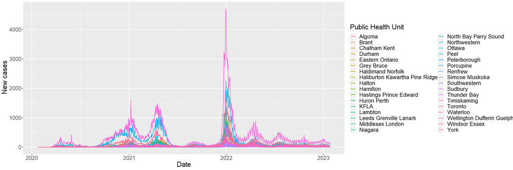

```r
# Update the aesthetics with axis and colour information, then add a line graph!
phu.plot +
    # 2. Aesthetics
    aes(x = date, y = new_cases, colour = public_health_unit) +
    theme(text = element_text(size = 20)) + # set text size
    guides(colour = guide_legend(title="Public Health Unit")) + # Legend title
    xlab("Date") + # Set the x-axis label
    ylab("New cases") + # Set the y-axis label

    # 4. Geoms
    geom_line()
```

## 4.2.0 Use the `facet_wrap()` command to break PHUs into separate graphs

There's a lot of data on that graph and some of it is quite drowned out because of the scale of PHUs with many more cases. To break out each PHU individually, we can add the `facet_wrap()` command. We'll also update some of the parameters:

- `scale`: we will update this so each y-axis scale is determined by PHU-specific data.
- `ncol`: use this to set the number of columns displayed in our grid

At the same time, we'll also get rid of the legend since each individual graph will be labeled by its PHU.

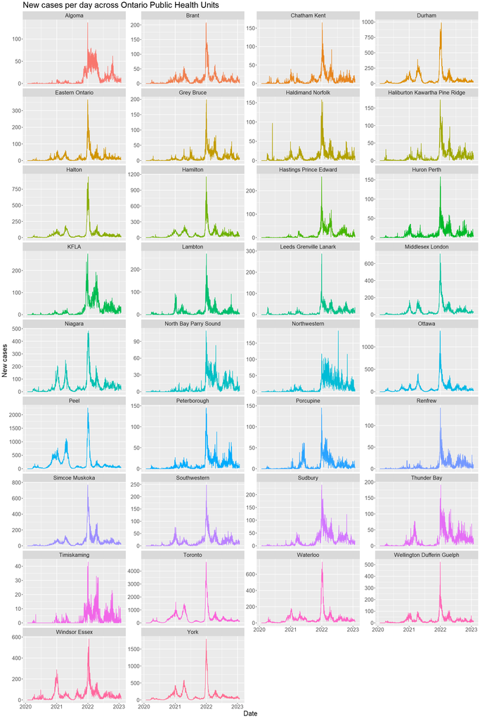

```r
# This is going to be a big graph so adjust our plot window sizes for us
options(repr.plot.width=20, repr.plot.height=30)

# Add a facet_wrap and get rid of the legend
phu_facet.plot <- phu.plot +
    # 2. Aesthetics
    aes(x = date, y = new_cases, colour = public_health_unit) +

    theme(text = element_text(size = 20)) + # set text size

    # Give titles to your axes
    xlab("Date") + # Set the x-axis label
    ylab("New cases") + # Set the y-axis label
    ggtitle("New cases per day across Ontario Public Health Units") +

    # Remove the legend
    theme(legend.position = "none") +

    # 4. Geoms
    geom_line() +

    # 7. ### 4.2.0 Facet our data by PHU
    facet_wrap(~ public_health_unit, scales = "free_y", ncol=4)

# Display our plot
phu_facet.plot
```

## 4.3.0 Use the `ggsave()` command to save your plots to a file

There are a number of ways you can use the `ggsave()` command to specify how you want to save your files.

```r
# What is our working director?
getwd()

# Save the plot we've generated to the root directory of the lecture files.
ggsave(plot = phu_facet.plot, filename = "data/Ontario_phu_data.all.facet.png", scale=2, device = "png", units = c("cm"))

# Take a look at the directory
dir("data/")
```

'C:/Users/mokca/Dropbox/!CAGEF/Course_Materials/Advanced_Graphics_in_R/2023.03_Adv_Graphics_R/Lecture_01_R_Introduction'

```
Saving 33.9 x 33.9 cm image
```

1. 'hospitalizations_pt.csv'

2. 'Lecture01.RData'

3. 'Ontario_covidtesting.csv'

4. 'Ontario_daily_change_in_cases_by_phu.csv'

5. 'Ontario_daily_change_in_cases_by_phu_long.RData'

6. 'Ontario_daily_change_in_cases_by_phu_long.tsv'

7. 'Ontario_phu_data.all.facet.png'

8. 'region_hospital_icu_covid_data.csv'

## 4.4.0 Barplots can be used to summarize your data across PHUs

Although we do have a running total for each date, what if we want to look at the totals cases across subsets of the PHUs? Using a barplot we can stack cases by date and get a sense of daily case totals from which sets of PHUs we desire.

This time we will use `geom_bar()` to display our data and tell it to use the values from our `new_cases` variable to generate the totals. We do this by setting the `stat = "identity"` parameter.

At the same time, let's update our colours to use a colour-blind friendly palette scheme.

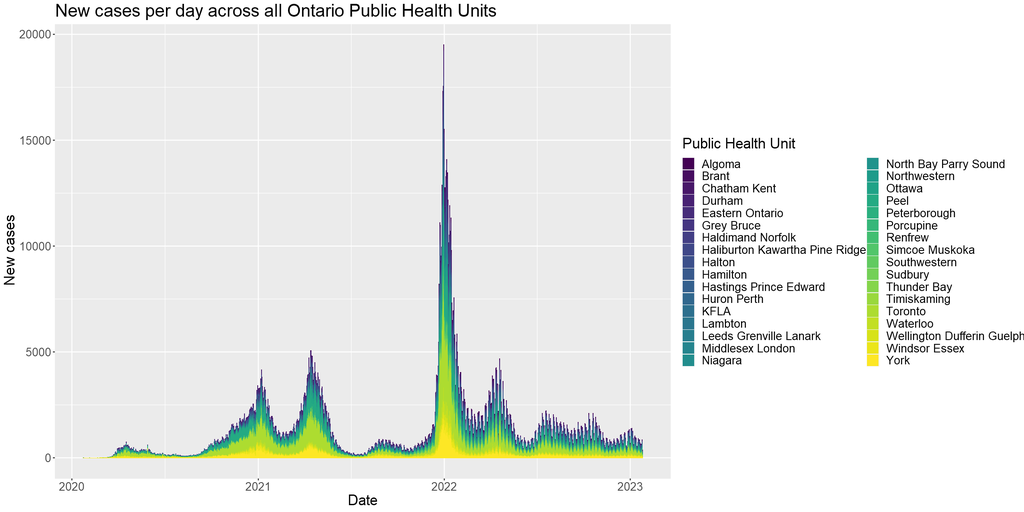

```r
# This is going to be a simpler graph so adjust our plot window size accordingly
options(repr.plot.width=20, repr.plot.height=10)

phu.plot +
    # 2. Aesthetics
    aes(x = date, y= new_cases, fill = public_health_unit) + # set our fill colour instead of line colour

    theme(text = element_text(size = 20)) + # set text size
    guides(fill = guide_legend(title="Public Health Unit")) +

    # Give titles to your axes
    xlab("Date") + # Set the x-axis label
    ylab("New cases") + # Set the y-axis label
    ggtitle("New cases per day across all Ontario Public Health Units") +

    # Set up our barplot here
    geom_bar(stat = "identity") +
    scale_fill_viridis_d() # the "d" stands for discrete colour scale
```

### 4.4.1 Alter your bin widths to monthly totals by transforming your x-axis

From above we get a sense of overall totals for some PHU distributions but it's still too much to look at. Let's transform our x-axis values so we can bin by months instead. To accomplish this we'll use the `as.yearmon()` function found in the `zoo` package we loaded at the beginning of the lecture.

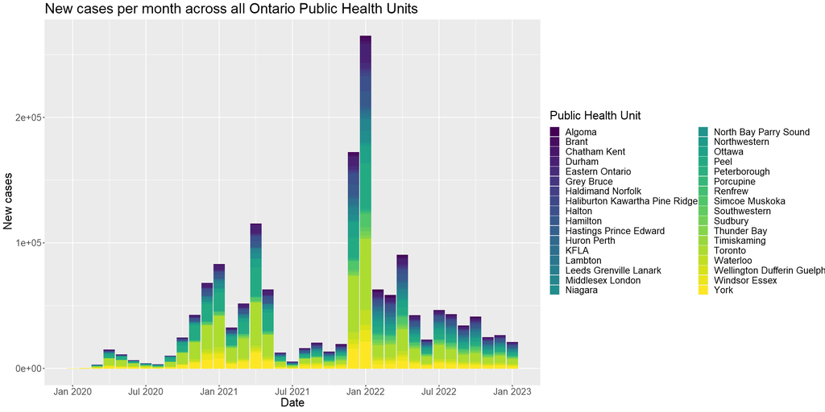

```r
phu.plot +
    # 2. Aesthetics
    aes(x = as.yearmon(date), ### 4.4.1 Update the x-axis by transforming the values to year-month format
        y= new_cases,
        fill = public_health_unit) + # set our fill colour instead of line colour

    theme(text = element_text(size = 20)) + # set text size
    guides(fill = guide_legend(title="Public Health Unit")) +

    # Give titles to your axes
    xlab("Date") + # Set the x-axis label
    ylab("New cases") + # Set the y-axis label
    ggtitle("New cases per month across all Ontario Public Health Units") +

    # Set up our barplot here
    geom_bar(stat = "identity") +
    scale_fill_viridis_d() # the "d" stands for discrete colour scale
```

## 4.5.0 Filter your data for what you want to display

Now that we have taken an initial look at our data, we can see that even after converting our axis to a month-year format, it appears that some of the data isn't that relevant for us. Some of the PHUs are not generating many new cases per day so we can now consider slicing our data up to look at specific regions.

Let's look at the top 10 regions by total caseload across the dataset.

```r
# What are the top 10 regions by total caseload?
covid_phu_long.df %>%

# group the data by public health unit
group_by(public_health_unit) %>%

# Summarize it by the total number of new cases in each PHU
summarise(total_cases = sum(new_cases)) %>%

# Sort all of the data in descending order by total cases
arrange(desc(total_cases)) %>%

# take the top 10 PHUs
.[1:10, ]
```

A tibble: 10 × 2

| public_health_unit <fct> | total_cases <dbl> |
| --- | --- |
| Toronto | 375424 |
| Peel | 205898 |
| York | 130251 |
| Ottawa | 89068 |
| Hamilton | 72789 |
| Durham | 72373 |
| Halton | 57093 |
| Simcoe Muskoka | 56390 |
| Waterloo | 55382 |
| Windsor Essex | 52481 |

```r
# Generate a list of all PHUs and sort by total caseload
# Generate a list of all PHUs and sort by total caseload
phu_by_total_cases_desc <- covid_phu_long.df %>%

# Group by public health unit
group_by(public_health_unit) %>%

# Based on public health unit, sum the total cases
summarise(total_cases = sum(new_cases)) %>%

# Sort by descending order
arrange(desc(total_cases)) %>%

# Grab the PHU names and convert them into a character vector
select(public_health_unit) %>%
unlist() %>%
as.character() # Coercion to a vector removes the names. unname() works as well.

# Take a look at the public health units
print(phu_by_total_cases_desc)
```

```
 [1] "Toronto"                        "Peel"
 [3] "York"                           "Ottawa"
 [5] "Hamilton"                       "Durham"
 [7] "Halton"                         "Simcoe Muskoka"
 [9] "Waterloo"                       "Windsor Essex"
[11] "Niagara"                        "Middlesex London"
[13] "Wellington Dufferin Guelph"     "KFLA"
[15] "Sudbury"                        "Eastern Ontario"
[17] "Thunder Bay"                    "Southwestern"
[19] "Lambton"                        "Brant"
[21] "Northwestern"                   "Hastings Prince Edward"
[23] "Leeds Grenville Lanark"         "Haliburton Kawartha Pine Ridge"
[25] "Algoma"                         "Grey Bruce"
[27] "Haldimand Norfolk"              "Chatham Kent"
[29] "Peterborough"                   "Huron Perth"
[31] "Porcupine"                      "North Bay Parry Sound"
[33] "Renfrew"                        "Timiskaming"
```

### 4.5.1 Use the `filter()` command to make a subset of our data

Now that we have a list of PHUs ordered by descending total cases, we can use that to filter our `covid_phu_long.df` dataframe and graph only the more heavily infected PHUs. We can then pipe the filtered data over to make a `ggplot()` object. At the same time we'll do a few more things:

1. Reorder our factors so that the bars and legend display the PHUs in ascending order by new cases.
2. Alter the plot title to reflect the data we are using.

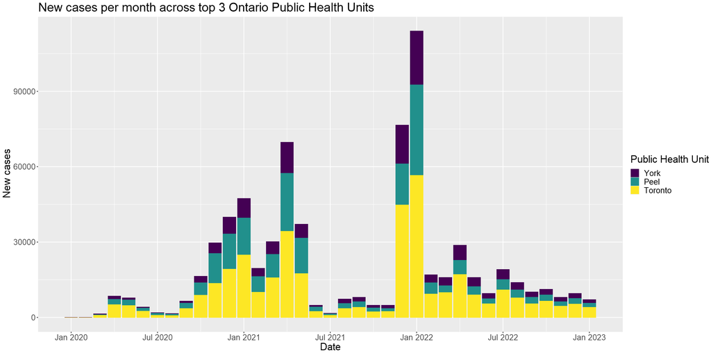

```r
# Make a bar graph
covid_phu_long.df %>%

### 4.5.1 Filter our data based on the PHUs we want to see
filter(public_health_unit %in% phu_by_total_cases_desc[1:3]) %>%

# Redirect our new data frame to ggplot
ggplot(.) +
    # 2. Aesthetics
    aes(x = as.yearmon(date),
        y= new_cases,
        fill = fct_reorder(public_health_unit, new_cases)) + # reordering the levels of the data supplied

    theme(text = element_text(size = 20)) + # set text size
    guides(fill = guide_legend(title="Public Health Unit")) +

    # Give titles to your axes
    xlab("Date") + # Set the x-axis label
    ylab("New cases") + # Set the y-axis label
    ggtitle("New cases per month across top 3 Ontario Public Health Units") +

    # Set up our barplot here
    geom_bar(stat = "identity") +
    scale_fill_viridis_d() # the "d" stands for discrete colour scale
```

## 4.6.0 Looking at the effect of lockdown on new cases

We can see from our first graph of daily case loads that there can be quite a bit of variability from day to day. Rather than look at the daily tally of new cases, perhaps we can take into account the overall number of new cases appearing in a 14-day sliding window. Given that symptoms from time of infection can take between 5-14 days to manifest, then a portion of daily positive cases can be the result of infection going back as far as 14-days. Taking a look at a 14-day mean average will also smooth out our data as we see below:

[figure not shown]

To accomplish the above visualization, we'll need to perform some transformations on our dataset.

1. Ensure our data is grouped by public health unit
2. Summarise our data in sliding windows of 14-day length

We'll want to track observations by:

- public health unit
- cases in the window
- window start date
- window end date

```r
# Shut down some output information from the summarise function
options(dplyr.summarise.inform = FALSE)

# 1. group our data by public health unit
covid_phu_long.df <- covid_phu_long.df %>% group_by(public_health_unit)

# 2. get a complete list of case dates
case.dates <- unique(covid_phu_long.df$date)

# 3. set up a table to hold our summarised results
phu_window_data.df = data.frame(public_health_unit = character(0),
                               window_mean = numeric(0),
                               start_date = numeric(0), end_date = numeric(0))

case_window = 14-1

# Iterate through the dates in a 14-day sliding window
for (i in 1:(length(case.dates)-case_window)) {

    curr.set <- covid_phu_long.df %>%
                # Filter for a set of data that spans 14 days
                filter(date %in% case.dates[i:(i + case_window)]) %>%
                # Summarize that data based on public health unit
                summarize(window_mean = mean(new_cases))

    # Track the start and end dates of the window
    curr.set$start_date = case.dates[i]
    curr.set$end_date = case.dates[i + case_window]

    # Add this table to the collected data
    phu_window_data.df <- rbind(phu_window_data.df, curr.set)
}

# Check on the final structure of the data
str(phu_window_data.df)
```

```
tibble [36,924 x 4] (S3: tbl_df/tbl/data.frame)
 $ public_health_unit: Factor w/ 34 levels "Algoma","Brant",..: 1 2 3 4 5 6 7 8 9 10 ...
 $ window_mean       : num [1:36924] 0 0 0 0 0 0 0 0 0 0 ...
 $ start_date        : Date[1:36924], format: "2020-01-23" "2020-01-23" ...
 $ end_date          : Date[1:36924], format: "2020-02-05" "2020-02-05" ...
```

### 4.6.1 Plot our windowed data as a line graph

Now that we've generated our windowed data, let's plot the top 5 PHUs by caseload. Let's also annotate some dates from the our pandemic history:

### 4.6.2 Here's what we'll do:

1. Plot the windowed data filtered by the top 5 PHUs
2. Clean up the graph a little bit by "simplifying" the themes
3. Annotate 4 dates from the pandemic timeline

### 4.6.3 Additional layers we'll see:

1. `theme()`: we can use this layer to access any number of elements regarding the overall look/feel of our visualization
2. `scale_*`: the scale layers allow us to alter the parameters of how our axis values are calculated or even colours of various components!
3. `geom_text()`: used to directly add text based on a mix of variables pulled from your data or specific start/end points
4. `annotate()`: a layer to overlay components onto your visualization like shapes, or arrows etc.

In the coming weeks we'll be digging into the meaning of these more but for this week, it's a bit of a trial by fire/memory.

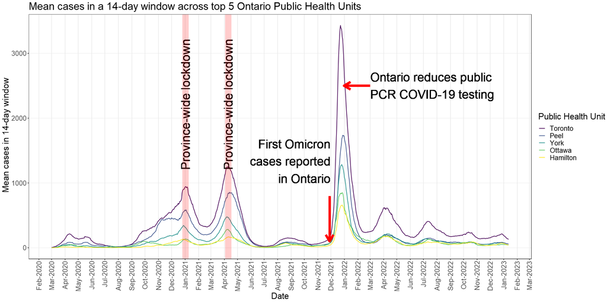

```r
# Build our plot and save to an object
phu_window.plot <- phu_window_data.df %>%
# Filter for the top 5 infected PHUs
filter(public_health_unit %in% phu_by_total_cases_desc[1:5]) %>%

# redirect the filtered result to ggplot
ggplot(.) +
    # 2. Aesthetics
    aes(x = start_date, y = window_mean, colour = fct_reorder(public_health_unit, window_mean, .desc=TRUE)) +

    theme_bw() + # Simplify the theme
    xlab("Date") +
    ylab("Mean cases in 14-day window") +
    ggtitle("Mean cases in a 14-day window across top 5 Ontario Public Health Units") +

    theme(text = element_text(size = 20)) + # set text size
    guides(colour = guide_legend(title="Public Health Unit")) + # set our legend name
    theme(panel.grid.major.y = element_line(color="grey95")) + # darken our major y grid
    theme(panel.grid.minor.y = element_blank()) + # remove our minor y grid
    theme(panel.grid.minor.x = element_blank()) + # remove our minor x grid
    theme(axis.text.x = element_text(angle = 90, hjust = 1, vjust = 0.5)) + # rotate our x-axis text

    # 3. Scaling
    # Start looking at data from March 2020 onwards
    scale_x_date(limits = c(as.Date("2020-03-01"), as.Date(max(phu_window_data.df$start_date))),
                 date_breaks = "1 month", date_labels = "%b-%Y") +

    scale_color_viridis_d() +

    # 4. Geoms
    geom_line(linewidth=1.5) + # Note that "size=1.5" works here too but is deprecated

    # Winter 2020 lockdown
    geom_text(aes(x=as.Date("2020-12-26") + 7, label = "Province-wide lockdown", y=2200),
              angle=90, size=10, colour="black") +
    annotate("rect", xmin=as.Date("2020-12-26"), xmax=as.Date("2020-12-26") + 14,
             ymin=-Inf, ymax=Inf, fill="red", alpha=0.2) +

    # Spring 2021 Lockdown
    geom_text(aes(x=as.Date("2021-04-03") + 7, label = "Province-wide lockdown", y=2200),
              angle=90, size=10, colour="black") +
    annotate("rect", xmin=as.Date("2021-04-03"), xmax=as.Date("2021-04-03") + 14,
             ymin=-Inf, ymax=Inf, fill="red", alpha=0.2) +

    # Omicron arrives
    geom_text(aes(x=as.Date("2021-11-30"), label = "First Omicron\ncases reported\nin Ontario", y=1000),
              hjust=1, vjust = 0, size=10, colour="black") +
    annotate("segment", x=as.Date("2021-11-28"), xend = as.Date("2021-11-28"),
             y=800, yend=100, colour="red", size = 2, arrow = arrow()) +

    # Ontario ends proper PCR testing
    geom_text(aes(x=as.Date("2022-03-01"), label = "Ontario reduces public\nPCR COVID-19 testing", y=2500),
              hjust=0, size=10, colour="black") +
    annotate("segment", x=as.Date("2022-03-01"), xend = as.Date("2021-12-31"),
             y=2500, yend=2500, colour="red", size = 2, arrow = arrow())

# plot our object to standard output
phu_window.plot

# If you wanted to save your plot:
# ggsave(phu_window.plot, file="images/top5_PHU_cases_14d-window.png", scale=1, device = "png", units = c("in"), width=20, height=10)
```

## 4.7.0 Don't forget to the hospitalization data!

One of the last things we want to cover before wrapping up is the importance of grouping your data and summarizing it. This paradigm is often a simple and powerful way to generate summary information about your various data groups/experiments.

To this end, let's look at the COVID hospitalization data by importing `region_hospital_ic_covid_data.csv` from our data folder. This gives us an idea of the stress being applied to the healthcare system and can also give us an idea of how severe the pandemic may be from wave to wave.

```r
# Import the hospitalization data
covid_hospitalizations <- read_csv("data/region_hospital_icu_covid_data.csv")

# Take a quick look
str(covid_hospitalizations)

# How many regions are there?
unique(covid_hospitalizations$oh_region)
```

```
spec_tbl_df [5,285 x 9] (S3: spec_tbl_df/tbl_df/tbl/data.frame)
 $ date                    : Date[1:5285], format: "2020-04-02" "2020-04-03" ...
 $ oh_region               : chr [1:5285] "CENTRAL" "CENTRAL" "CENTRAL" "CENTRAL" ...
 $ icu_current_covid       : num [1:5285] 51 57 65 65 73 83 85 92 88 90 ...
 $ icu_current_covid_vented: num [1:5285] 39 52 57 55 58 68 68 73 73 77 ...
 $ hospitalizations        : num [1:5285] 113 141 143 174 187 183 203 205 218 230 ...
 $ icu_crci_total          : num [1:5285] 0 0 0 0 0 0 0 0 0 0 ...
 $ icu_crci_total_vented   : num [1:5285] 0 0 0 0 0 0 0 0 0 0 ...
 $ icu_former_covid        : num [1:5285] 0 0 0 0 0 0 0 0 0 0 ...
 $ icu_former_covid_vented : num [1:5285] 0 0 0 0 0 0 0 0 0 0 ...
 - attr(*, "spec")=
  .. cols(
  ..   date = col_date(format = ""),
  ..   oh_region = col_character(),
  ..   icu_current_covid = col_double(),
  ..   icu_current_covid_vented = col_double(),
  ..   hospitalizations = col_double(),
  ..   icu_crci_total = col_double(),
  ..   icu_crci_total_vented = col_double(),
  ..   icu_former_covid = col_double(),
  ..   icu_former_covid_vented = col_double()
  .. )
 - attr(*, "problems")=<externalptr>
```

1. 'CENTRAL'

2. 'EAST'

3. 'NORTH'

4. 'TORONTO'

5. 'WEST'

### 4.7.1 Use the `group_by()` and `summarize()` paradigm to analyse data

So it looks like our hospitalization data begins around April 2020 and includes multiple metrics involving the status of ICU patients bu also the number of current hospitalizations. There is also a variable `oh_region` which should denote the health region from which the data is sampled.

The 5 regions reported can vary in size and resources but we can combine these regions into single values to look at the overall number of hospitalizations on a daily basis. To accomplish this feat we'll turn to the `group_by()` and `summarize()` functions.

The key to using these is to identify the goals of your analysis. In the current case, we want to combine all 5 health regions into a singular one *based on* the `date` variable. From there we wish to calculate the `sum()` of each *group* on a variable like `hospitalizations`.

```r
# Pass the hospitalization data
covid_hospitalizations %>%
    # Group the data by DATE
    group_by(date) %>%
    # Summarize each group as a sum of "hospitalizations" and "icu_current_covid"
    summarize(all_curr_hospitalizations = sum(hospitalizations)) %>%

    # Take a look at the data
    head()
```

A tibble: 6 × 2

| date <date> | all_curr_hospitalizations <dbl> |
| --- | --- |
| 2020-04-02 | 407 |
| 2020-04-03 | 446 |
| 2020-04-04 | 475 |
| 2020-04-05 | 508 |
| 2020-04-06 | 576 |
| 2020-04-07 | 597 |

### 4.7.2 Plot our data using the same code

Now that we know how to summarize the data, we can work on visualizating it. For the purposes of comparison, we can reuse our code from before and simply substitute in the new parameters for our visualizations (ie `x` and `y` values).

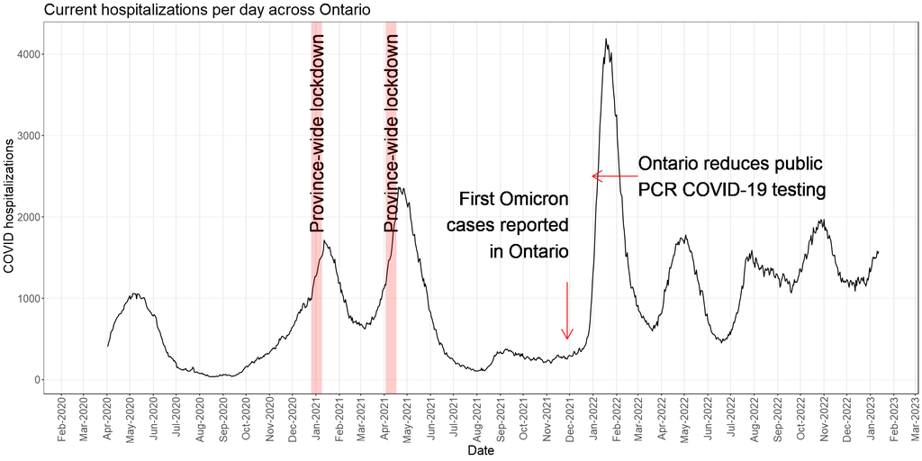

```r
# Pass the hospitalization data
covid_hospitalizations %>%
    # Group the data by DATE
    group_by(date) %>%
    # Summarize each group as a sum of "hospitalizations"
    summarize(all_curr_hospitalizations = sum(hospitalizations)) %>%

# redirect the filtered result to ggplot
ggplot(.) +
    ### 2. Aesthetics: update the x and y sources
    aes(x = date, y = all_curr_hospitalizations) +

    theme_bw() + # Simplify the theme
    xlab("Date") +
    ylab("COVID hospitalizations") +
    ggtitle("Current hospitalizations per day across Ontario") +

    theme(text = element_text(size = 20)) + # set text size
    theme(panel.grid.major.y = element_line(color="grey95")) + # darken our major y grid
    theme(panel.grid.minor.y = element_blank()) + # remove our minor y grid
    theme(panel.grid.minor.x = element_blank()) + # remove our minor x grid
    theme(axis.text.x = element_text(angle = 90, hjust = 1, vjust = 0.5)) + # rotate our x-axis text

    # 3. Scaling
    # Start looking at data from March 2020 onwards
    scale_x_date(limits = c(as.Date("2020-03-01"), as.Date(max(phu_window_data.df$start_date))),
                 date_breaks = "1 month", date_labels = "%b-%Y") +

    scale_color_viridis_d() +

    # 4. Geoms
    geom_line(linewidth=1.5) +

    # Winter 2020 lockdown
    geom_text(aes(x=as.Date("2020-12-26") + 7, label = "Province-wide lockdown", y=1800),
              angle=90, hjust = 0, size=10, colour="black") +
    annotate("rect", xmin=as.Date("2020-12-26"), xmax=as.Date("2020-12-26") + 14,
             ymin=-Inf, ymax=Inf, fill="red", alpha=0.2) +

    # Spring 2021 Lockdown
    geom_text(aes(x=as.Date("2021-04-03") + 7, label = "Province-wide lockdown", y=1800),
              angle=90, hjust = 0, size=10, colour="black") +
    annotate("rect", xmin=as.Date("2021-04-03"), xmax=as.Date("2021-04-03") + 14,
             ymin=-Inf, ymax=Inf, fill="red", alpha=0.2) +

    # Omicron arrives
    geom_text(aes(x=as.Date("2021-11-30"), label = "First Omicron\ncases reported\nin Ontario", y=1500),
              hjust=1, vjust = 0, size=10, colour="black") +
    annotate("segment", x=as.Date("2021-11-28"), xend = as.Date("2021-11-28"),
             y=1200, yend=500, colour="red", linewidth = 2, arrow = arrow()) +

    # Ontario ends proper PCR testing
    geom_text(aes(x=as.Date("2022-03-01"), label = "Ontario reduces public\nPCR COVID-19 testing", y=2500),
              hjust=0, size=10, colour="black") +
    annotate("segment", x=as.Date("2022-03-01"), xend = as.Date("2021-12-31"),
             y=2500, yend=2500, colour="red", linewidth = 2, arrow = arrow())
```

Well it looks like our hospitalization data tells a different story from the case report data! Something worth exploring in your assignment!

# 5.0.0 Class summary

That's our first class! If we've made it this far, we've reviewed

1. Foundational concepts in R
2. Helpful functions in generating tidy data for analysis
3. Basics of visualizations using the `ggplot2`

We took a "messy" dataset from the Ontario government and created a tidy data set that we were able to visualize. We took that further by transforming the data into a 14-day sliding window of mean new cases per day in each public health unit. This clarified our picture of cases and visually confirmed that spread of SARS-CoV-2 does appear to be mitigated through lockdown orders.

Next week? Getting deeper into `ggplot2`!

## 5.1.0 Weekly assignment

This week's assignment will be found under the current lecture folder under the "assignment" subfolder. It will include a Jupyter notebook that you will use to produce the code and answers for this week's assignment. Please provide answers in markdown or code cells that immediately follow each question section.

|  | Assignment breakdown |  |
| --- | --- | --- |
| Code | 50% | - Does it follow best practices? |
|  |  | - Does it make good use of available packages? |
|  |  | - Was data prepared properly |
| Answers and Output | 50% | - Is output based on the correct dataset? |
|  |  | - Are groupings appropriate |
|  |  | - Are correct titles/axes/legends correct? |
|  |  | - Is interpretation of the graphs correct? |

Since coding styles and solutions can differ, students are encouraged to use best practices. Assignments *may* be rewarded for well-coded or elegant solutions.

You can save and download the Jupyter notebook in its native format. Submit this file to the the appropriate assignment section by 9:59 am on the date of our next class: March 14th, 2023.

## 5.2.0 Acknowledgements

**Revision 1.0.0**: created and prepared for **CSB1021H S LEC0141**, 03-2021 by Calvin Mok, Ph.D. *Bioinformatician, Education and Outreach, CAGEF.*

**Revision 1.0.1**: edited and prepared for **CSB1020H S LEC0141**, 03-2022 by Calvin Mok, Ph.D. *Bioinformatician, Education and Outreach, CAGEF.*

**Revision 1.0.2**: edited and prepared for **CSB1020H S LEC0141**, 03-2023 by Calvin Mok, Ph.D. *Bioinformatician, Education and Outreach, CAGEF.*

## 5.3.0 References

1. Coercion from "R in a Nutshell": https://www.oreilly.com/library/view/r-in-a/9781449358204/ch05s08.html
2. Tibbles vs data frames from "RStudio blog": https://blog.rstudio.com/2016/03/24/tibble-1-0-0/
3. Indexing elements from a vector or list: https://cran.r-project.org/doc/manuals/R-lang.html#Indexing
4. Change the levels of a factor: http://www.cookbook-r.com/Manipulating_data/Changing_the_order_of_levels_of_a_factor/
5. The apply family of functions: https://www.r-bloggers.com/2015/07/r-tutorial-on-the-apply-family-of-functions/
6. Tidy data principles: https://cran.r-project.org/web/packages/tidyr/vignettes/tidy-data.html
7. Using the `lubridate` package: https://r4ds.had.co.nz/dates-and-times.html

# 6.0.0 Appendix 1: Instructions for installing your own software

## 6.1.0 Jupyter Notebooks and the R kernel

For this introductory course we will be teaching and running code for R through Jupyter notebooks. In this section we will discuss

1. Installation of Jupyter (through Anaconda)
2. Updating the default R package
3. Starting up your Jupyter notebooks

### 6.1.1 Installing R and Jupyter Notebooks (via Anaconda3)

As of 2022-10-17, The latest version of Anaconda3 runs with Python 3.9

Download the OS-appropriate version from here https://www.anaconda.com/products/individual

- Remember to choose the correct OS
- All versions should come with Python 3.9 (3.10 windows 64-bit version)
- Windows:
  - Use the graphical installer
  - 64- vs. 32-bit is dependent on your version of windows
- MacOS:
  - It is likely easier to use the graphical installer vs. the command line version
- Unix:
  - Choose the 64-bit installer best for your linux OS

### 6.1.2 Updating the base version of R

As of 2023-03-01, the lastest version of r-base available for Anaconda is 4.1.3 (Windows) or 4.2.2 (macOS and Linux) and Anaconda does not appear to come with a pre-installed version of R.

To save time, we will update just our r-base (version) through the command line using the Anaconda prompt. You'll need to find the menu shortcut to the prompt in order to run these commands. Before class you should update all of your anaconda packages. This will be sure to get you the latest version of Jupyter notebook. Open up the Anaconda prompt and type the following command:

`conda update --all`

It will ask permission to continue at some point. Say 'yes' to this. After this is completed, use the following command:

`conda install -c conda-forge/label/main r-base=4.1.3=hdca333a_5` (Windows)

`conda install -c conda-forge/label/main r-base=4.2.2=h841e2fe_3` (MacOS)

`conda install -c conda-forge/label/main r-base=4.2.2=ha7d60f8_3` (MacOS)

Anaconda will try to install a number of R-related packages. Say 'yes' to this.

### 6.1.3 Loading the R-kernel for your Jupyter notebook

Lastly, we want to connect your R version to the Jupyter notebook itself. Type the following command:

`conda install -c r r-irkernel`

Jupyter should now have R integrated into it. No need to build an extra environment to run it.

### 6.1.3.1 A quick note about Anaconda environments

`conda create -n my_R_env -c conda-forge/label/main r-base=4.1.3=hdca333a_5`

This would create a new environment with version **4.1.3** of R but the **base** version of Anaconda would retain version its previous version of R. A small but helpful detail if you are unsure about newer versions of packages that you'd like to use.

Likewise, you can update and install packages in new environments without affecting or altering your base environment! Again it's helpful if you're upgrading or installing new packages and programs. If you're not sure how it will affect what you already have in place, you can just install them straight into an environment.

For more information: https://docs.conda.io/projects/conda/en/latest/user-guide/tasks/manage-environments.html#cloning-an-environment

### 6.1.3.2 Using the Anaconda navigator to make a Jupyter notebook

If you are inclined, the Anaconda Navigator can help you make an R environment separate from the base, but you won't be able to perform the same fancy tricks as in the prompt, like installing new packages directly to a new environment.

**Note:** You should consider doing this only if you have a good reason to isolate what you're doing in R from the Anaconda base packages. You will also need to have installed r-base 4.0.3 to make a new environment with it through the Anaconda navigator.

The Anaconda navigator is a graphical interface that shows all fo your pre-installed packages and give you access to installing other common programs like RStudio (we'll get to that in a moment).

- Open up your Anaconda Navigator
- Click on "Environments" in the left-hand pane.
- Click on the "Create" icon at the bottom of the middle pane
- You'll receive a dialog window for "Create New Environment".
- Name your environment **"R-4-1-3"**
- Make sure the packages for **Python** (3.9) and **R** (r) are checked off.
- Click on the "Create" button and wait patiently for your environment to be created

You will now have an R environment where you can install specific R packages that won't make their way into your Anaconda base.

- After the environment is made, you can left-click on the green triangle of R-4-0-3
- Choose "Open with Jupyter Notebook" from the dropdown menu.

You will likely find a shortcut to this environment in your (Windows) menu under the Anaconda folder. It will look something like **Jupyter Notebook (R-4-0-3)**

### 6.1.3.3 Installing packages for your personal Jupyter Notebook

Normally I suggest avoiding installing packages through your Jupyter Notebook. Instead, if you want to update your R packages for running Jupyter, it's best to add them through either the Anaconda prompt or Anaconda navigator. Again, using the prompt gives you more options but can seem a little more complicated.

One of the most useful packages to install for R is r-essentials. Open up the Anaconda prompt and use the command: `conda install -c r r-essentials`. After running, the Anaconda prompt will inform you of any package dependencies and it will identify which packages will be updated, newly installed, or removed (unlikely).

Anaconda has multiple channels (similar to repositories) that exist and are maintained by different groups. These various channels port over regular R packages to a format that can be installed in Anaconda and run by R. The two main channels you'll find useful for this are the `r` channel and `conda-forge` channel. You can find more information about all of the packages on [docs.anaconda.com](https://docs.anaconda.com/anaconda/packages/r-language-pkg-docs/). As you might have guessed the basic format for installing packages is this: `conda install -c channel-name r-package` where

`conda-install` is the call to install packages. This can be done in a base or custom environment `-c channel-name` identifies that you wish to name a specific channel to install from `r-package` is the name of your package and most of them will begin with `r-` ie `r-ggplot2`

## 6.2.0 R and RStudio

### 6.2.1 Installing R

As of 2022-03-01, the latest stable R version is 4.2.1:

Windows:

```
- Go to <http://cran.utstat.utoronto.ca/>
- Click on 'Download R for Windows'
- Click on 'install R for the first time'
- Click on 'Download R 4.2.1 for Windows' (or a newer version)
- Double-click on the .exe file once it has downloaded and follow the instructions.
```

(Mac) OS X:

```
- Go to <http://cran.utstat.utoronto.ca/>
- Click on 'Download R for (Mac) OS X'
- Click on R-4.2.1 .pkg (or a newer version)
- Open the .pkg file once it has downloaded and follow the instructions.
```

Linux:

```
- Open a terminal (Ctrl + alt + t)
- sudo apt-get update
- sudo apt-get install r-base
- sudo apt-get install r-base-dev (so you can compile packages from source)
```

### 6.2.2 Installing RStudio

As of 2023-03-01, the latest RStudio version is 2022.12.0+353 (released 2022-12-15)

Windows (10/11):

```
- Go to <https://posit.co/downloads/>
- Click on 'RSTUDIO-2022.12.0-353.EXE' to download the installer (or a newer version)
- Double-click on the .exe file once it has downloaded and follow the instructions.
```

(Mac) OS X (11+):

```
- Go to <https://posit.co/downloads/>
- Click on 'RSTUDIO-2022.12.0-353.DMG' to download the installer (or a newer version)
- Double-click on the .dmg file once it has downloaded and follow the instructions.
```

Linux:

```
- Go to <https://posit.co/downloads/>
- Click on the installer that describes your Linux distribution, e.g. 'RSTUDIO-2022.12.0-353-AMD64.DEB' (or a newer version)
- Double-click on the .deb file once it has downloaded and follow the instructions.
- If double-clicking on your .deb file did not open the software manager, open the terminal (Ctrl + alt + t) and type **sudo dpkg -i /path/to/installer/RSTUDIO-2022.12.0-353-AMD64.deb**

 _Note: You have 3 things that could change in this last command._
 1. This assumes you have just opened the terminal and are in your home directory. (If not, you have to modify your path. You can get to your home directory by typing cd ~.)
 2. This assumes you have downloaded the .deb file to Downloads. (If you downloaded the file somewhere else, you have to change the path to the file, or download the .deb file to Downloads).
 3. This assumes your file name for .deb is the same as above. (Put the name matching the .deb file you downloaded).
```

If you have a problem with installing R or RStudio, you can also try to solve the problem yourself by Googling any error messages you get. You can also try to get in touch with me or the course TAs.

### 6.2.3 Getting to know the RStudio environment

RStudio is an IDE (Integrated Development Environment) for R that provides a more user-friendly experience than using R in a terminal setting. It has 4 main areas or panes, which you can customize to some extent under `Tools > Global Options > Pane Layout`:

1. **Source** - The code you are annotating and keeping in your script.
2. **Console** - Where your code is executed.
3. **Environment** - What global objects you have created and functions you have written/sourced.  
   History - A record of all the code you have executed in the console.  
   Connections - Which data sources you are connecting to. (Not being used in this course.)
4. **Files, Plots, Packages, Help, Viewer** - self-explanatoryish if you click on their tabs.

All of the panes can be minimized or maximized using the large and small box outlines in the top right of each pane.

[figure not shown]

### 6.2.3.1 Source

To run your current line of code or a highlighted segment of code from the Source pane you can:  
a) click the button `'Run' -> 'Run Selected Line(s)'`,  
b) click `'Code' -> 'Run Selected Line(s)'` from the menu bar,  
c) use the keyboard shortcut `CTRL + ENTER` (Windows & Linux) `Command + ENTER` (Mac) (recommended),  
d) copy and paste your code into the Console and hit `Enter` (not recommended).

There are always many ways to do things in R, but the fastest way will always be the option that keeps your hands on the keyboard.

### 6.2.3.2 Console

You can also type and execute your code (by hitting `ENTER`) in the **Console** when the `>` prompt is visible. If you enter code and you see a `+` instead of a prompt, R doesn't think you are finished entering code (i.e. you might be missing a bracket). If this isn't immediately fixable, you can hit `Esc` twice to get back to your prompt. Using the up and down arrow keys, you can find previous commands in the Console if you want to rerun code or fix an error resulting from a typo.

On the Console tab in the top left of that pane is your current working directory. Pressing the arrow next to your working directory will open your current folder in the Files pane. If you find your Console is getting too cluttered, selecting the broom icon in that pane will clear it for you. The Console also shows information: upon start up about R (such as version number), during the installation of packages, when there are warnings, and when there are errors.

### 6.2.3.3 Environment

In the **Global Environment** you can see all of the stored objects you have created or sourced (imported from another script). The Global Environment can become cluttered, so it also has a broom button to clear its workspace.

**Objects** are made by using the assignment operator `<-`. On the left side of the arrow, you have the name of your object. On the right side you have what you are assigning to that object. In this sense, you can think of an object as a container. The container holds the values given as well as information about 'class' and 'methods' (which we will come back to).

Type `x <- c(2,4)` in the Console followed by `Enter`. 1D objects' data types can be seen immediately as well as their first few values. Now type `y <- data.frame(numbers = c(1,2,3), letters = c("a","b","c"))` in the Console followed by `Enter`. You can immediately see the dimension of 2D objects, and you can check the structure of data frames and lists (more later) by clicking on the object's arrow. Clicking on the object name will open the object to view in a new tab. Custom functions created in session or sourced will also appear in this pane.

The Environment pane dropdown displays all of the currently loaded packages in addition to the Global Environment. *Loaded* means that all of the tools/functions in the package are available for use. R comes with a number of packages pre-loaded (i.e. base, grDevices).

In the History tab are all of the commands you have executed in the Console during your session. You can select a line of code and send it to the Source or Console.

The Connections tab is to connect to data sources such as Spark and will not be used in this lesson.

### 6.2.3.4 Files, Plots, Packages, Help, Viewer

The Files tab allows you to search through directories; you can go to or set your working directory by making the appropriate selection under the `More` (blue gear) drop-down menu. The `...` to the top left of the pane allows you to search for a folder in a more traditional manner.

The Plots tab is where plots you make in a .R script will appear (notebooks and markdown plots will be shown in the Source pane). There is the option to Export and save these plots manually.

The Packages tab has all of the packages that are installed and their versions, and buttons to Install or Update packages. A check mark in the box next to the package means that the package is loaded. You can load a package by adding a check mark next to a package, however it is good practice to instead load the package in your script to aid in reproducibility.

The Help menu has the documentation for all packages and functions. For each function you will find a description of what the function does, the arguments it takes, what the function does to the inputs (details), what it outputs, and an example. Some of the help documentation is difficult to read or less than comprehensive, in which case goggling the function is a good idea.

The Viewer will display vignettes, or local web content such as a Shiny app, interactive graphs, or a rendered html document.

### 6.2.3.5 Global Options

I suggest you take a look at `Tools -> Global Options` to customize your experience.

For example, under `Code -> Editing` I have selected `Soft-wrap R source files` followed by `Apply` so that my text will wrap by itself when I am typing and not create a long line of text.

You may also want to change the `Appearance` of your code. I like the `RStudio theme: Modern` and `Editor font: Ubuntu Mono`, but pick whatever you like! Again, you need to hit `Apply` to make changes.

That whirlwind tour isn't everything the IDE can do, but it is enough to get started.

## The Center for the Analysis of Genome Evolution and Function (CAGEF)

The Centre for the Analysis of Genome Evolution and Function (CAGEF) at the University of Toronto offers comprehensive experimental design, research, and analysis services in microbiome and metagenomic studies, genomics, proteomics, and bioinformatics.

From targeted DNA amplicon sequencing to transcriptomes, whole genomes, and metagenomes, from protein identification to post-translational modification, CAGEF has the tools and knowledge to support your research. Our state-of-the-art facility and experienced research staff provide a broad range of services, including both standard analyses and techniques developed by our team. In particular, we have special expertise in microbial, plant, and environmental systems.

For more information about us and the services we offer, please visit https://www.cagef.utoronto.ca/.

[figure not shown]